# SELECTION SIGNATURES - POPULATION GENETICS

BIO - 641 | Prof. Dr. Kaio Olimpio

Caio Cruz, Italo Sardinha, MUhammad e Vitor Bialetzki Cristiano

19/10/2026

# INTRODUCTION

Plant domestication involves evolutionary processes like genetic drift, inbreeding, natural selection, and active selection, which together have shaped diverse livestock breeds adapted to various environments. While natural selection improves survival and reproductive fitness, artificial selection is split into ancient unconscious selection and deliberate, goal oriented methodical selection. These selection strategies drive changes in specific genomic regions controlling traits such as morphology, production performance, behavior, adaptation, and disease resistance. The unique genetic footprints left behind in these regions are called selection signatures. When a new beneficial mutation rapidly reaches fixation, it reduces genetic variability in neighboring neutral sites, a phenomenon known as a selective sweep, hitchhiking effect, or genetic draft. Studying genomic variation in *Zea mays* L. helps us understand the genetic architecture of complex traits, population demography, and the evolutionary mechanisms driven by selection. This analysis uses genotyping data from the NCBI GEO repository under accession GSE50558, which includes 2,233 doubled haploid lines derived from 24 biparental populations alongside their 23 parents, genotyped using the Illumina MaizeSNP50 BeadChip. The dataset covers two half sib germplasm panels: the Dent panel (CFD prefix), containing 1,005 lines, and the Flint panel (CFF prefix), containing 1,262 lines. The analytical approach follows two main steps. First, we present a descriptive analysis of the population structure. Second, we apply statistical tests to detect selection signatures across the genome.

## Methods for detection of selection signatures

The study of selection signatures has evolved from comparing species-level divergence to scanning population-level variations across the genome. In the 1990s, early methods evaluated selective pressures at a macroevolutionary scale by comparing gene substitution patterns between distinct species. Key approaches from this era included the Hudson-Kreitman-Aguadé (HKA) test, the McDonald-Kreitman test (MKT), and the $dN/dS$ ratio ($\omega$ or $Ka/Ks$). The $dN/dS$ statistic measures the ratio of non-synonymous substitution rates ($dN$, under selection) to synonymous substitution rates ($dS$, neutral):

- $dN/dS > 1$: Indicates positive selection.
- $dN/dS < 1$: Indicates negative (purifying) selection.
- $dN/dS = 1$: Indicates neutral evolution.

While these traditional tests effectively identified evolutionary events from the distant past, advances in high-throughput sequencing and dense SNP arrays shifted the focus toward microevolutionary events occurring within species at the population level. Modern genome-wide scans now rely on statistical frameworks categorized into two main groups:1.

### Intra-Population Statistics

Intra-population statistics search for footprints of selection by analyzing genomic variation within a single population. These methods fall into three main categories:

Site Frequency Spectrum (SFS): Detects shifts in allele frequency distributions caused by selective sweeps (e.g., Tajima’s $D$).

Linkage Disequilibrium (LD): Measures extended haplotype conservation surrounding beneficial mutations.

Reduced Local Variability: Identifies genomic regions with reduced diversity, such as long Runs of Homozygosity (ROH).

### Inter-Population Statistics

Inter-population statistics detect selection signatures by measuring genetic differentiation between populations driven by divergent selection pressures:

Single-Site Differentiation: Evaluates allele frequency divergence locus by locus across populations (e.g., $F_{ST}$).

Haplotype-Based Differentiation: Examines shared and divergent haplotype structures across populations to increase detection power (e.g., $hapFLK$, $XP-EHH$).

### DATA PREPARATION

```r
rm(list = ls()); gc()
```

```
##           used (Mb) gc trigger (Mb) max used (Mb)
## Ncells  628563 33.6    1438305 76.9   714619 38.2
## Vcells 1205949  9.3    8388608 64.0  1977603 15.1
```

```r
setwd("~/Genetica de POP - Vitor")


library(data.table)
library(readr)
library(readxl)
library(tidyverse)
library(dplyr)
library(sommer)
library(tibble)
library(GEOquery)
library(rehh)
library(detectRUNS)
```

```r
# data: https://www.ncbi.nlm.nih.gov/geo/query/acc.cgi?acc=GSE50558
CFF_fixed <- read.delim(
  "GSE50558_CFF_matrix_GEO_fixed.txt.gz",
  header = TRUE,
  sep = "\t",
  check.names = FALSE
)
##### o arquivo original esta errado, nenhum pacote ou funcao no R consegue ler de forma correta, tem que arrumar no terminal, usar esse comando:
# histidine@histidine:~/Genetica de POP - Vitor$ gzip -cd GSE50558_CFF_matrix_GEO.txt.gz | perl -ne '$cr++ while /\r/g; $lf++ while /\n/g; $crlf++ while /\r\n/g; END { print "CR=$cr LF=$lf CRLF=$crlf\n" }'
# CR=112222 LF=56111 CRLF=56111
# histidine@histidine:~/Genetica de POP - Vitor$ gzip -cd GSE50558_CFD_matrix_GEO.txt.gz | perl -ne '$cr++ while /\r/g; $lf++ while /\n/g; $crlf++ while /\r\n/g; END { print "CR=$cr LF=$lf CRLF=$crlf\n" }'
# CR=56111 LF=56111 CRLF=56111
# histidine@histidine:~/Genetica de POP - Vitor$ gzip -cd GSE50558_CFF_matrix_GEO.txt.gz |
# tr -d '\r' |
# gzip > GSE50558_CFF_matrix_GEO_fixed.txt.gz

dim(CFF_fixed)

CFD <- read.delim("GSE50558_CFD_matrix_GEO.txt.gz", header = TRUE)

dim(CFD)
head(CFD)


Parental <- read.delim("GSE50558_Parental_matrix_GEO.txt.gz")

## Fazer um controle de qualidade, nao preciosa, os autores ja falaram que fizeram,
#"The processed and filtered data were used to construct genetic linkage maps which we used in our study of variation of recombination rate in maize."
################################################################################

### pegar apenas os snps e os top.alleles

## DENT
cols_CFDENT <- c("ID_REF", grep("\\.Top\\.Alleles$", colnames(CFD), value = TRUE))
matriz_CFDENT <- CFD[, cols_CFDENT]

setnames(matriz_CFDENT,
         old = colnames(matriz_CFDENT),
         new = gsub("\\.Top\\.Alleles$", "", colnames(matriz_CFDENT)))

for (j in setdiff(colnames(matriz_CFDENT), "ID_REF")) {
  set(matriz_CFDENT, i = which(matriz_CFDENT[[j]] %in% c("NC", "NN", "--", "", "N N")), j = j, value = NA)
}

if ("ID_REF" %in% colnames(matriz_CFDENT)) {
  snp_ids <- matriz_CFDENT[["ID_REF"]]
  matriz_CFDENT <- as.matrix(matriz_CFDENT[, colnames(matriz_CFDENT) != "ID_REF"])
  rownames(matriz_CFDENT) <- snp_ids
}

# Transpor: Indivíduos nas LINHAS x SNPs nas COLUNAS
matriz_CFDENT <- t(matriz_CFDENT)
matriz_CFDENT[matriz_CFDENT %in% c("NC", "NN", "N N", "--", "", "NA", "N/N")] <- NA

cat("Convertendo DENT com atcg1234...\n")
matriz_CFDENT <- atcg1234(
  data   = matriz_CFDENT,
  format = "ATCG",
  maf    = 0,
  imp    = FALSE
)

matriz_CFDENT <- as.matrix(matriz_CFDENT$M)



################################################################################

## FLINT

cols_CFFLINT <- c("ID_REF", grep("Top[ .]Alleles$", colnames(CFF_fixed), value = TRUE))
matriz_CFFLINT <- CFF_fixed[, cols_CFFLINT]

setnames(matriz_CFFLINT,
         old = colnames(matriz_CFFLINT),
         new = gsub("Top[ .]Alleles$", "", colnames(matriz_CFFLINT)))

for (j in setdiff(colnames(matriz_CFFLINT), "ID_REF")) {
  set(matriz_CFFLINT, i = which(matriz_CFFLINT[[j]] %in% c("NC", "NN", "--", "", "N N")), j = j, value = NA)
}

if ("ID_REF" %in% colnames(matriz_CFFLINT)) {
  snp_ids <- matriz_CFFLINT[["ID_REF"]]
  matriz_CFFLINT <- as.matrix(matriz_CFFLINT[, colnames(matriz_CFFLINT) != "ID_REF"])
  rownames(matriz_CFFLINT) <- snp_ids
}

# Transpor: Indivíduos nas LINHAS x SNPs nas COLUNAS
matriz_CFFLINT <- t(matriz_CFFLINT)
matriz_CFFLINT[matriz_CFFLINT %in% c("NC", "NN", "N N", "--", "", "NA", "N/N")] <- NA

cat("Convertendo DENT com atcg1234...\n")
matriz_CFFLINT <- atcg1234(
  data   = matriz_CFFLINT,
  format = "ATCG",
  maf    = 0,
  imp    = FALSE
)

matriz_CFFLINT <- as.matrix(matriz_CFFLINT$M)


################################################################################

## PARENTAIS

cols_Parental <- c("ID_REF", grep("Top[ .]Alleles$", colnames(Parental), value = TRUE))
matriz_Parental <- Parental[, cols_Parental] #criar o df

setnames(matriz_Parental, #### tirar o top allees
         old = colnames(matriz_Parental),
         new = gsub(".Top[ .]Alleles$", "", colnames(matriz_Parental)))



for (j in setdiff(colnames(matriz_Parental), "ID_REF")) {
  set(matriz_Parental, i = which(matriz_Parental[[j]] %in% c("NC", "NN", "--", "", "N N")), j = j, value = NA)
}### aqui so coloca na


if ("ID_REF" %in% colnames(matriz_Parental)) {
  snp_ids <- matriz_Parental$ID_REF
  matriz_Parental <- as.matrix(matriz_Parental[, colnames(matriz_Parental) != "ID_REF"])
  rownames(matriz_Parental) <- snp_ids
}



matriz_Parental <- t(matriz_Parental)
matriz_Parental[matriz_Parental %in% c("NC", "NN", "N N", "--", "", "NA", "N/N")] <- NA

cat("Convertendo com atcg1234...\n")
matriz_Parental <- atcg1234(
  data   = matriz_Parental,
  format = "ATCG",
  maf    = 0,
  imp    = FALSE
)


matriz_Parental <- matriz_Parental$M

matriz_Parental <- t(matriz_Parental)

snps_comuns <- intersect(
  colnames(matriz_CFDENT),
  colnames(matriz_CFFLINT)
)

matriz_CFDENT<- matriz_CFDENT[, snps_comuns, drop = FALSE]
matriz_CFFLINT<- matriz_CFFLINT[, snps_comuns, drop = FALSE]
cat("Número de SNPs compartilhados mantidos:", length(snps_comuns), "\n")
```

### Organization of the Genomic Data

```r
##### PARTE GENOMICA, CALCULAR DESEQUILIBRIUM E ETC... REMOVER OS GRAFICOS DEPOIS  DE USAR



### instalar os pacotes para baizar diretp dp GEO
# if (!requireNamespace("BiocManager", quietly = TRUE)) {
#   install.packages("BiocManager")
# }
#
# if (!requireNamespace("GEOquery", quietly = TRUE)) {
#   BiocManager::install("GEOquery")
# }

### aqui pega os dados para fazer o mapa genetico no link : https://www.ncbi.nlm.nih.gov/geo/query/acc.cgi?acc=GPL17677
gpl <- getGEO("GPL17677", destdir = ".")

# Conferir a anotação
# Extrair a tabela completa
anotacao <- GEOquery::Table(gpl)

# Conferir as colunas
names(anotacao)
```

```
##  [1] "ID"                              "IlmnID"
##  [3] "RSID"                            "SSID"
##  [5] "B73_v2_chr"                      "B73_v2_BP"
##  [7] "IlmnStrand"                      "SNP"
##  [9] "AddressA_ID"                     "AlleleA_ProbeSeq"
## [11] "AddressB_ID"                     "AlleleB_ProbeSeq"
## [13] "GenomeBuild"                     "B73_v1_chr"
## [15] "B73_v1_MapInfo"                  "Ploidy"
## [17] "Species"                         "Source"
## [19] "SourceVersion"                   "SourceStrand"
## [21] "SourceSeq"                       "TopGenomicSeq"
## [23] "BeadSetID"                       "Exp_Clusters"
## [25] "MaizeSNP50_A.bpm.GenTrain Score" "MaizeSNP50_A.bpm.Cluster Sep"
## [27] "SPOT_ID"
```

```r
# Selecionar as informações relevantes
mapa_SNPs <- anotacao %>%
  transmute(
    SNP = as.character(ID),
    IlmnID = IlmnID,
    RSID = RSID,
    chr = as.character(B73_v2_chr),
    pos = suppressWarnings(as.numeric(B73_v2_BP))
  ) %>%
  distinct(SNP, .keep_all = TRUE)

head(mapa_SNPs)
```

```
##        SNP                    IlmnID        RSID chr       pos
## 1 abph1.15 abph1.15-0_T_F_1605158166 rs131175417   2  27482871
## 2 abph1.22 abph1.22-0_T_F_1605156962 rs131175416   2  27482777
## 3    ae1.4    ae1.4-0_B_R_1605157313 rs131175700   5 168468333
## 4    ae1.8  ae1.8-128_T_F_1768567587 rs131175699   5 168463281
## 5    an1.3    an1.3-0_T_F_1605157644 rs131175334   1 241222672
## 6    ba1.5    ba1.5-0_T_R_1605156958 rs131175538   3 183084768
```

```r
dim(mapa_SNPs)
```

```
## [1] 56110     5
```

```r
################################################################################
################################################################################
# 2. Criar uma tabela de correspondência entre identificadores
# A ordem estabelece prioridade: ID, IlmnID e RSID.

mapa_para_match <- bind_rows(
  mapa_SNPs %>%
    transmute(
      marcador = SNP,
      SNP, IlmnID, RSID, chr, pos
    ),
  mapa_SNPs %>%
    transmute(
      marcador = IlmnID,
      SNP, IlmnID, RSID, chr, pos
    ),
  mapa_SNPs %>%
    transmute(
      marcador = RSID,
      SNP, IlmnID, RSID, chr, pos
    )
) %>%
  filter(!is.na(marcador), marcador != "") %>%
  distinct(marcador, .keep_all = TRUE)

# 3. Associar cada SNP compartilhado à anotação física
mapa_comuns <- tibble(marcador = snps_comuns) %>%
  left_join(mapa_para_match, by = "marcador")

# 4. Diagnosticar o resultado
cat("SNPs compartilhados:", length(snps_comuns), "\n")
## SNPs compartilhados: 40719
cat("SNPs com posição física:",
    sum(!is.na(mapa_comuns$chr) &
          !is.na(mapa_comuns$pos)), "\n")
## SNPs com posição física: 40719
cat("SNPs sem posição física:",
    sum(is.na(mapa_comuns$chr) |
          is.na(mapa_comuns$pos)), "\n")
## SNPs sem posição física: 0

# 5. Manter apenas SNPs com cromossomo e posição válidos
mapa_haplotipos <- mapa_comuns %>%
  filter(
    !is.na(chr),
    !is.na(pos),
    chr != "",
    is.finite(pos)
  ) %>%
  mutate(
    chr = as.character(chr),
    pos = as.numeric(pos)
  ) %>%
  arrange(chr, pos) %>%
  distinct(marcador, .keep_all = TRUE)

# 6. Reordenar as duas matrizes segundo o mapa físico
snps_ordenados <- mapa_haplotipos$marcador

matriz_CFDENT_mapa <- matriz_CFDENT[
  , snps_ordenados, drop = FALSE
]

matriz_CFFLINT_mapa <- matriz_CFFLINT[
  , snps_ordenados, drop = FALSE
]

# 7. Conferir o alinhamento
stopifnot(
  identical(
    colnames(matriz_CFDENT_mapa),
    colnames(matriz_CFFLINT_mapa)
  ),
  identical(
    colnames(matriz_CFDENT_mapa),
    mapa_haplotipos$marcador
  )
)

head(mapa_haplotipos)
```

```
## # A tibble: 6 × 6
##   marcador               SNP                    IlmnID         RSID  chr     pos
##   <chr>                  <chr>                  <chr>          <chr> <chr> <dbl>
## 1 PHM14519.8             PHM14519.8             PHM14519.8-0_… rs13… 0         0
## 2 PHM3630.8              PHM3630.8              PHM3630.8-0_B… rs13… 0         0
## 3 PHM4955.12             PHM4955.12             PHM4955.12-0_… rs13… 0         0
## 4 PUT-163a-101389210-16  PUT-163a-101389210-16  PUT-163a-1013… rs13… 0         0
## 5 PUT-163a-101392844-22  PUT-163a-101392844-22  PUT-163a-1013… rs13… 0         0
## 6 PUT-163a-110528154-112 PUT-163a-110528154-112 PUT-163a-1105… rs13… 0         0
```

```r
dim(mapa_haplotipos)
```

```
## [1] 40719     6
```

```r
dim(matriz_CFDENT_mapa)
```

```
## [1]  1005 40719
```

```r
dim(matriz_CFFLINT_mapa)
```

```
## [1]  1262 40719
```

```r
################################################################################
################################################################################


# Remover marcadores do cromossomo zero
mapa_haplotipos <- mapa_haplotipos %>%
  filter(chr != "0")%>%
  filter(chr != "99")

# Atualizar a ordem dos SNPs
snps_ordenados <- mapa_haplotipos$marcador

# Selecionar os mesmos SNPs nas duas matrizes
matriz_CFDENT_mapa <- matriz_CFDENT[
  , snps_ordenados, drop = FALSE
]

matriz_CFFLINT_mapa <- matriz_CFFLINT[
  , snps_ordenados, drop = FALSE
]

# Conferir os resultados
table(mapa_haplotipos$chr)
```

```
##
##    1   10    2    3    4    5    6    7    8    9
## 6386 2874 4669 4591 4267 4399 3327 3362 3472 3023
```

```r
dim(mapa_haplotipos)
```

```
## [1] 40370     6
```

```r
dim(matriz_CFDENT_mapa)
```

```
## [1]  1005 40370
```

```r
dim(matriz_CFFLINT_mapa)
```

```
## [1]  1262 40370
```

```r
# Confirmar alinhamento
stopifnot(
  identical(colnames(matriz_CFDENT_mapa),
            colnames(matriz_CFFLINT_mapa)),
  identical(colnames(matriz_CFDENT_mapa),
            mapa_haplotipos$marcador)
)

################################################################################
################################################################################

mapa_haplotipos %>%
  group_by(chr) %>%
  summarise(
    n_SNPs = n(),
    pos_min = min(pos, na.rm = TRUE),
    pos_max = max(pos, na.rm = TRUE),
    ordenado = all(diff(pos) >= 0),
    .groups = "drop"
  )
```

```
## # A tibble: 10 × 5
##    chr   n_SNPs pos_min   pos_max ordenado
##    <chr>  <int>   <dbl>     <dbl> <lgl>
##  1 1       6386    3498 301296235 TRUE
##  2 10      2874  628920 149919736 TRUE
##  3 2       4669   10232 236974575 TRUE
##  4 3       4591  529680 232094969 TRUE
##  5 4       4267   29441 241240700 TRUE
##  6 5       4399   80997 217706489 TRUE
##  7 6       3327  129643 169103335 TRUE
##  8 7       3362   32899 176145738 TRUE
##  9 8       3472   65513 175733619 TRUE
## 10 9       3023   67801 156589940 TRUE
```

```r
table(
  unlist(matriz_CFDENT_mapa),
  useNA = "ifany"
)
```

```
##
##        0        1        2     <NA>
## 18287069   158178 20532400  1594203
```

```r
table(
  unlist(matriz_CFFLINT_mapa),
  useNA = "ifany"
)
```

```
##
##        0        1        2     <NA>
## 22271183   241686 26137430  2296641
```

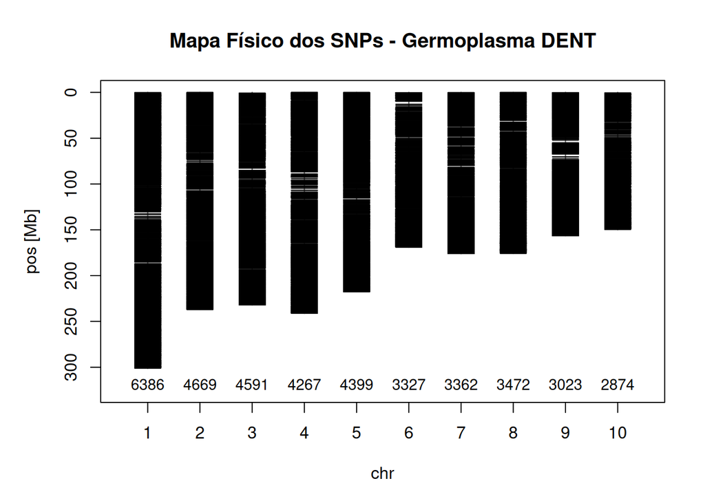

```r
################################################################################
# PREPARAÇÃO DOS DADOS DO MAPA FÍSICO
################################################################################

mapa_plot <- mapa_haplotipos %>%
  filter(!is.na(chr), !is.na(pos), chr != "0", chr != "99") %>%
  mutate(
    chr = as.numeric(chr),
    pos_mb = pos / 1e6
  ) %>%
  arrange(chr, pos_mb)

# Paleta de cores para o LD (r² de 0 a 1)
col_palette <- colorRampPalette(c("#FEE5D9", "#FCAE91", "#FB6A4A", "#DE2D26", "#A50F15", "#67000D"))(100)

get_color <- function(r2) {
  if (is.na(r2)) return("grey90")
  idx <- round(r2 * 99) + 1
  idx <- max(1, min(100, idx))
  return(col_palette[idx])
}

################################################################################
# FUNÇÕES GERADORAS DOS GRÁFICOS (ESTILO FIG 9.2 E FIG 9.5)
################################################################################

# 1. Função para o Mapa Físico / Densidade de Marcadores (Fig 9.2)
plot_mapa_posicao <- function(mapa_info, titulo_pop) {
  chrs <- sort(unique(mapa_info$chr))
  max_y <- max(mapa_info$pos_mb, na.rm = TRUE) * 1.08
  width <- 0.25

  par(mfrow = c(1, 1), mar = c(5, 5, 4, 2))
  plot(1, type = "n",
       xlim = c(0.5, length(chrs) + 0.5),
       ylim = c(max_y, 0),
       xaxt = "n",
       xlab = "chr",
       ylab = "pos [Mb]",
       main = paste("Mapa Físico dos SNPs - Germoplasma", titulo_pop))

  axis(1, at = 1:length(chrs), labels = chrs)

  for (i in seq_along(chrs)) {
    c <- chrs[i]
    sub_map <- mapa_info %>% filter(chr == c)

    lines(c(i, i), c(0, max(sub_map$pos_mb)), col = "grey40", lwd = 1.2)
    segments(x0 = i - width, y0 = sub_map$pos_mb,
             x1 = i + width, y1 = sub_map$pos_mb,
             col = "black", lwd = 0.7)
    text(x = i, y = max_y * 0.98, labels = nrow(sub_map), cex = 0.9)
  }
}

# 2. Função para o Heatmap de LD Adjacente r² (Fig 9.5)
plot_heatmap_ld <- function(matriz_genotipos, mapa_info, titulo_pop) {
  chrs <- sort(unique(mapa_info$chr))
  max_y <- max(mapa_info$pos_mb, na.rm = TRUE) * 1.08
  width <- 0.25

  layout(matrix(c(1, 2), nrow = 1), widths = c(5, 1))

  par(mar = c(5, 5, 4, 2))
  plot(1, type = "n",
       xlim = c(0.5, length(chrs) + 0.5),
       ylim = c(max_y, 0),
       xaxt = "n",
       xlab = "chr",
       ylab = "pos [Mb]",
       main = paste("LD (r²) entre Marcadores Adjacentes - Germoplasma", titulo_pop))

  axis(1, at = 1:length(chrs), labels = chrs)

  for (i in seq_along(chrs)) {
    c <- chrs[i]
    sub_map <- mapa_info %>% filter(chr == c)
    snps_chr <- sub_map$marcador
    pos_chr <- sub_map$pos_mb

    mat_chr <- matriz_genotipos[, snps_chr, drop = FALSE]
    n_snps <- length(snps_chr)

    if (n_snps > 1) {
      for (j in 1:(n_snps - 1)) {
        vec1 <- mat_chr[, j]
        vec2 <- mat_chr[, j + 1]

        r2 <- suppressWarnings(cor(vec1, vec2, use = "complete.obs")^2)
        col_rect <- get_color(r2)

        rect(xleft = i - width, ybottom = pos_chr[j],
             xright = i + width, ytop = pos_chr[j + 1],
             col = col_rect, border = col_rect)
      }
    }

    text(x = i, y = max_y * 0.98, labels = n_snps, cex = 0.9)
  }

  # Legenda do r²
  par(mar = c(5, 1, 4, 3))
  plot.new()
  plot.window(xlim = c(0, 1), ylim = c(0, 1))
  text(x = 0.5, y = 1.05, labels = expression(r^2), font = 2, xpd = TRUE)

  legend_image <- as.raster(matrix(rev(col_palette), ncol = 1))
  rasterImage(legend_image, 0.2, 0.1, 0.5, 0.9)
  rect(0.2, 0.1, 0.5, 0.9)
  axis(4, at = seq(0.1, 0.9, length.out = 6),
       labels = sprintf("%.1f", seq(0, 1, length.out = 6)),
       las = 1)

  layout(1)
}

################################################################################
# GERAR OS MAPAS SEPARADAMENTE
################################################################################

# --- 1. GERMOPLASMA DENT ---
plot_mapa_posicao(mapa_plot, "DENT")
```

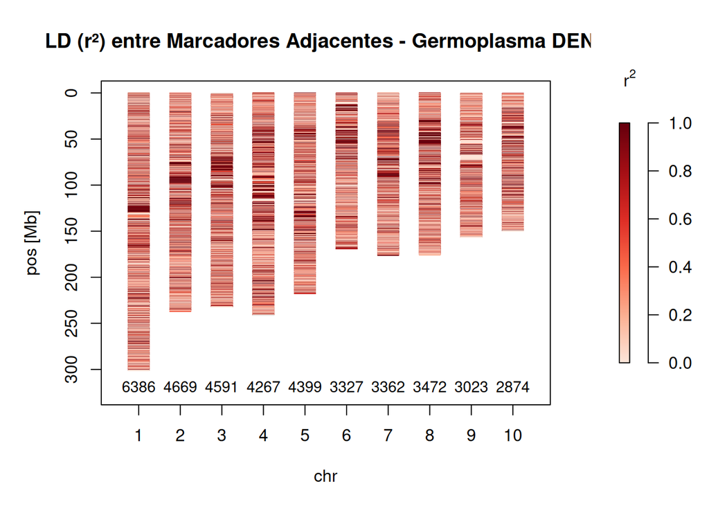

```r
plot_heatmap_ld(matriz_CFDENT_mapa, mapa_plot, "DENT")
```

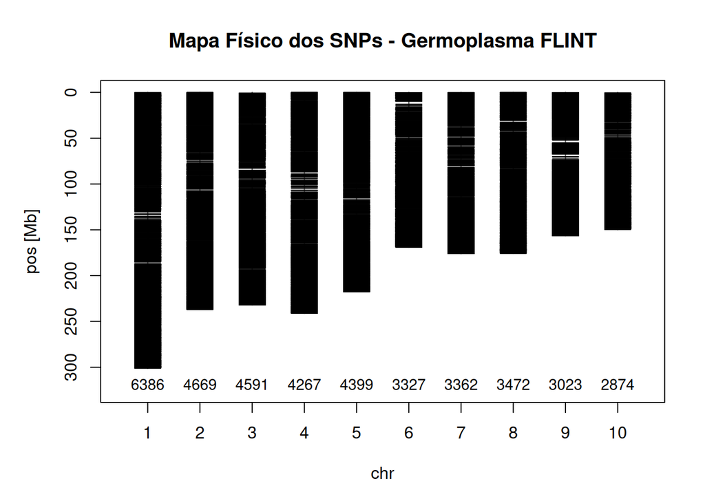

```r
# --- 2. GERMOPLASMA FLINT ---
plot_mapa_posicao(mapa_plot, "FLINT")
```

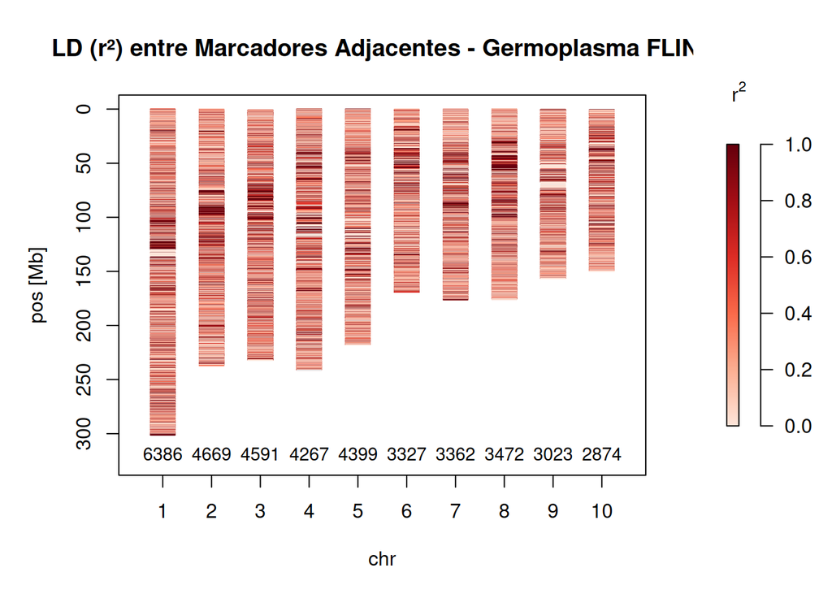

```r
plot_heatmap_ld(matriz_CFFLINT_mapa, mapa_plot, "FLINT")
```

### Site Frequency Spectrum

The Site Frequency Spectrum (SFS) represents the distribution of allele frequencies across polymorphic loci within a population. Under neutral evolutionary equilibrium (balancing genetic drift and mutation), the expected SFS follows a standard theoretical distribution where rare alleles outnumber common ones in a predictable decay curve.

Selective sweeps distort this baseline distribution. When an advantageous mutation rapidly rises in frequency, linked neutral variants “hitchhike” along with it. This process generates an excess of both low-frequency and high-frequency derived variants, while severely depleting intermediate-frequency alleles. To detect these spectral distortions across the genome, we employ two complementary neutrality tests: Tajima’s $D$ and Fay and Wu’s $H$.

#### Tajima’s $D$ Statistic

Tajima’s $D$ (Tajima, 1989) tests for departures from neutral expectations by comparing two distinct estimators of the population mutation parameter $\theta = 4N_e\mu$ (where $N_e$ is the effective population size and $\mu$ is the mutation rate per generation):

$\hat{\theta}_\pi$ (Tajima, 1983): Estimates $\theta$ based on the average number of pairwise nucleotide differences (heterozygosity):

$$\hat{\theta}_\pi = \sum_{i=1}^{n-1}
\frac{2 S_i \, i \, (n - i)}{n (n - 1)}$$
$\hat{\theta}_W$ (Watterson, 1975): Estimates $\theta$ based on the total number of segregating (polymorphic) sites ($S$):

$$\hat{\theta}_W = \frac{S}{a_1} = \left(
\sum_{i=1}^{n-1} \frac{1}{i} \right)^{-1} \sum_{i=1}^{n-1} S_i$$
Where:

- $n$ is the number of sampled chromosomes.
- $S_i$ is the number of polymorphic variants found $i$ times in the sample (site frequency spectrum count).
- $S = \sum_{i=1}^{n-1} S_i$ represents the total number of segregating sites.

Tajima’s $D$ statistic is calculated as the normalized difference between these two estimators:

$$D = \frac{\hat{\theta}_\pi -
\hat{\theta}_W}{\sqrt{\text{Var}(\hat{\theta}_\pi -
\hat{\theta}_W)}}$$
#### Fay and Wu’s $H$ Statistic

While Tajima’s $D$ effectively captures shifts in low-to-medium frequency variants, it cannot distinguish whether rare alleles are ancestral or derived. Fay and Wu (2000) introduced the $H$ statistic to specifically detect recent positive selection by identifying an excess of high-frequency derived alleles—a direct signature of genetic hitchhiking.

This method requires polarizing alleles into ancestral and derived states using an outgroup. Fay and Wu proposed an estimator, $\hat{\theta}_H$, which weights derived allele frequencies by their homozygosity:

$$\hat{\theta}_H = \sum_{i=1}^{n-1}
\frac{2 S_i \, i^2}{n (n - 1)}$$
The $H$ statistic measures the difference between pairwise nucleotide diversity ($\hat{\theta}_\pi$) and the high-frequency derived estimator ($\hat{\theta}_H$):
$$H = \hat{\theta}_\pi -
\hat{\theta}_H$$

#### Tajima’s $D$ Statistic and Fay and Wu’s $H$ Statistic Computation

```r
#####    CALCULAR Site frequency spectrum (SFS) based methods

# Filtrar mapa para manter apenas 1 SNP por posição física por cromossomo
mapa_haplotipos_unicos <- mapa_haplotipos %>%
  distinct(chr, pos, .keep_all = TRUE)

# atualizar vetor de SNPs ordenados e únicos
snps_unicos <- mapa_haplotipos_unicos$marcador

# filtrar as matrizes genotípicas
matriz_CFDENT_rehh  <- matriz_CFDENT_mapa[, snps_unicos, drop = FALSE]
matriz_CFFLINT_rehh <- matriz_CFFLINT_mapa[, snps_unicos, drop = FALSE]

# ver se ta tudo cerot
stopifnot(
  identical(colnames(matriz_CFDENT_rehh), mapa_haplotipos_unicos$marcador),
  identical(colnames(matriz_CFFLINT_rehh), mapa_haplotipos_unicos$marcador)
)


################################################################################
# FUNÇÃO AJUSTADA COM remove_multiple_markers = TRUE - (AI)
################################################################################

calcular_tajima_rehh <- function(matriz_genotipos, mapa_snps, pop_nome, window_size_bp = 2e6, overlap_bp = 5e5) {

  # Estruturar o mapa para o rehh
  mapa_rehh <- mapa_snps %>%
    transmute(
      marker_id = as.character(marcador),
      chr       = as.character(chr),
      pos       = as.numeric(pos)
    )

  # Recodificar dosagem (0, 1, 2) para a convenção "12"
  matriz_rehh <- matriz_genotipos
  matriz_recodificada <- matrix(0, nrow = nrow(matriz_rehh), ncol = ncol(matriz_rehh),
                                dimnames = dimnames(matriz_rehh))

  matriz_recodificada[matriz_rehh == 0] <- 1
  matriz_recodificada[matriz_rehh == 2] <- 2
  matriz_recodificada[matriz_rehh == 1 | is.na(matriz_rehh)] <- 0

  resultados_pop <- list()
  cromossomos <- sort(unique(as.numeric(mapa_rehh$chr)))

  for (c in cromossomos) {
    snps_chr <- mapa_rehh %>% filter(chr == as.character(c)) %>% pull(marker_id)
    mapa_chr <- mapa_rehh %>% filter(chr == as.character(c))

    mat_chr <- matriz_recodificada[, snps_chr, drop = FALSE]

    ids_ind <- if (!is.null(rownames(mat_chr))) rownames(mat_chr) else paste0("Ind_", 1:nrow(mat_chr))
    df_hap  <- cbind(ID = ids_ind, as.data.frame(mat_chr, stringsAsFactors = FALSE))

    tmp_hap <- tempfile(fileext = ".hap")
    tmp_map <- tempfile(fileext = ".map")

    write.table(df_hap, file = tmp_hap, row.names = FALSE, col.names = FALSE, quote = FALSE, sep = "\t")
    write.table(mapa_chr, file = tmp_map, row.names = FALSE, col.names = FALSE, quote = FALSE, sep = "\t")

    hh_obj <- tryCatch({
      data2haplohh(
        hap_file                = tmp_hap,
        map_file                = tmp_map,
        chr.name                = as.character(c),
        allele_coding           = "12",
        min_perc_geno.mrk       = 80,
        remove_multiple_markers = TRUE, # Remove automaticamente marcas com posições duplicadas
        verbose                 = FALSE
      )
    }, error = function(e) {
      warning(paste("Erro no cromossomo", c, ":", e$message))
      return(NULL)
    })

    unlink(c(tmp_hap, tmp_map))

    if (!is.null(hh_obj)) {
      res_sfs <- calc_sfs_tests(
        hh_obj,
        polarized   = FALSE,
        window_size = window_size_bp,
        overlap     = overlap_bp,
        min_n_mrk   = 5,
        verbose     = TRUE
      )

      if (!is.null(res_sfs) && nrow(res_sfs) > 0) {
        res_sfs$Populacao <- pop_nome
        resultados_pop[[length(resultados_pop) + 1]] <- res_sfs
      }
    }
  }

  return(bind_rows(resultados_pop))
}



# Rodar DENT
sfs_DENT <- calcular_tajima_rehh(
  matriz_genotipos = matriz_CFDENT_rehh,
  mapa_snps        = mapa_haplotipos_unicos,
  pop_nome         = "DENT",
  window_size_bp   = 2e6,
  overlap_bp       = 5e5
)

# Rodar FLINT
sfs_FLINT <- calcular_tajima_rehh(
  matriz_genotipos = matriz_CFFLINT_rehh,
  mapa_snps        = mapa_haplotipos_unicos,
  pop_nome         = "FLINT",
  window_size_bp   = 2e6,
  overlap_bp       = 5e5
)

head(sfs_DENT)
head(sfs_FLINT)

#INTERPRETACAO

# Unificar os dois conjuntos de dados
sfs_completo <- bind_rows(sfs_DENT, sfs_FLINT)

# 1. Resumo por Grupo Populacional
resumo_global <- sfs_completo %>%
  group_by(Populacao) %>%
  summarise(
    n_janelas       = n(),
    mean_TajimaD    = mean(TAJIMA_D, na.rm = TRUE),
    sd_TajimaD      = sd(TAJIMA_D, na.rm = TRUE),
    median_TajimaD  = median(TAJIMA_D, na.rm = TRUE),
    quant_1_perc    = quantile(TAJIMA_D, 0.01, na.rm = TRUE), # Limiar inferior (Sweeps)
    quant_99_perc   = quantile(TAJIMA_D, 0.99, na.rm = TRUE), # Limiar superior
    n_sweeps_neg1.5 = sum(TAJIMA_D < -1.5, na.rm = TRUE),
    .groups         = "drop"
  )


# 2. Resumo Detalhado por Cromossomo (1 a 10)
resumo_por_chr <- sfs_completo %>%
  group_by(Populacao, CHR) %>%
  summarise(
    n_janelas     = n(),
    mean_TajimaD  = mean(TAJIMA_D, na.rm = TRUE),
    min_TajimaD   = min(TAJIMA_D, na.rm = TRUE),
    n_sweeps_cand = sum(TAJIMA_D < -1.5, na.rm = TRUE),
    .groups       = "drop"
  )
```

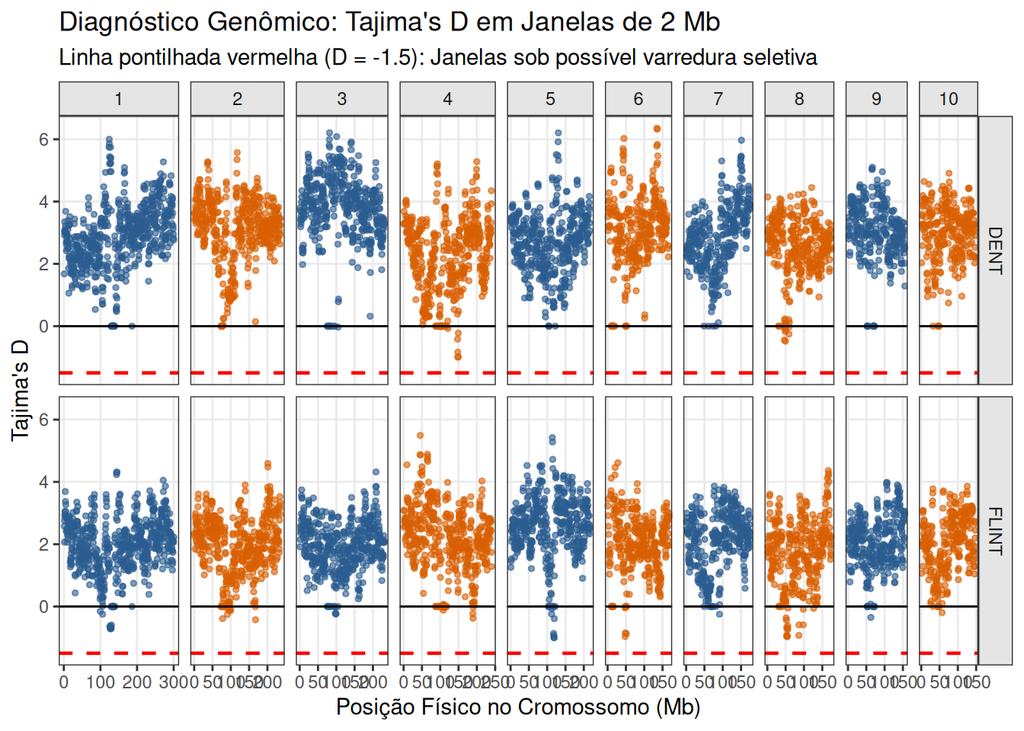

```r
# Graficos

sfs_plot <- sfs_completo %>%
  mutate(
    CHR = as.numeric(CHR),
    center_mb = ((START + END) / 2) / 1e6
  )

# Manhattan Plot Comparativo (DENT vs FLINT)
ggplot(sfs_plot, aes(x = center_mb, y = TAJIMA_D, color = as.factor(CHR))) +
  geom_point(alpha = 0.6, size = 1) +
  geom_hline(yintercept = 0, color = "black", linetype = "solid", size = 0.5) +
  geom_hline(yintercept = -1.5, color = "red", linetype = "dashed", size = 0.8) +
  facet_grid(Populacao ~ CHR, scales = "free_x", space = "free_x") +
  scale_color_manual(values = rep(c("#2B5C8F", "#D95F02"), 5)) +
  labs(
    title = "Diagnóstico Genômico: Tajima's D em Janelas de 2 Mb",
    subtitle = "Linha pontilhada vermelha (D = -1.5): Janelas sob possível varredura seletiva",
    x = "Posição Físico no Cromossomo (Mb)",
    y = "Tajima's D",
    color = "Cromossomo"
  ) +
  theme_bw() +
  theme(
    legend.position = "none",
    strip.background = element_rect(fill = "grey90"),
    panel.grid.minor = element_blank()
  )
```

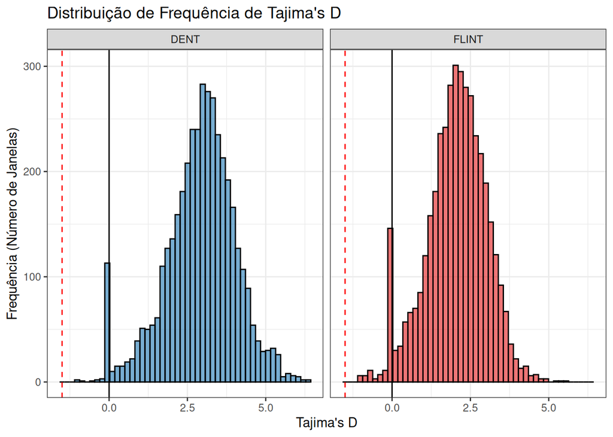

```r
################################################################################

ggplot(sfs_plot, aes(x = TAJIMA_D, fill = Populacao)) +
  geom_histogram(bins = 50, alpha = 0.6, position = "identity", color = "black") +
  geom_vline(xintercept = 0, linetype = "solid", color = "black") +
  geom_vline(xintercept = -1.5, linetype = "dashed", color = "red") +
  facet_wrap(~ Populacao) +
  scale_fill_manual(values = c("DENT" = "#1F78B4", "FLINT" = "#E31A1C")) +
  labs(
    title = "Distribuição de Frequência de Tajima's D",
    x = "Tajima's D",
    y = "Frequência (Número de Janelas)"
  ) +
  theme_bw() +
  theme(legend.position = "none")
```

```r
q01_dent  <- quantile(sfs_DENT$TAJIMA_D, 0.01, na.rm = TRUE)
q01_flint <- quantile(sfs_FLINT$TAJIMA_D, 0.01, na.rm = TRUE)

# Isolar as janelas do Top 1% mais extremas em cada grupo
sweeps_dent <- sfs_DENT %>%
  filter(TAJIMA_D <= q01_dent) %>%
  arrange(TAJIMA_D)

sweeps_flint <- sfs_FLINT %>%
  filter(TAJIMA_D <= q01_flint) %>%
  arrange(TAJIMA_D)

cat("=== DIAGNÓSTICO GERAL POR CROMOSSOMO ===\n")
## === DIAGNÓSTICO GERAL POR CROMOSSOMO ===
print(resumo_por_chr, n = 20)
```

```
## # A tibble: 20 × 6
##    Populacao CHR   n_janelas mean_TajimaD min_TajimaD n_sweeps_cand
##    <chr>     <chr>     <int>        <dbl>       <dbl>         <int>
##  1 DENT      1           599         2.85      0                  0
##  2 DENT      10          296         2.98      0                  0
##  3 DENT      2           470         3.10      0                  0
##  4 DENT      3           461         3.84     -0.0301             0
##  5 DENT      4           479         2.23     -0.995              0
##  6 DENT      5           432         2.70      0                  0
##  7 DENT      6           335         3.05      0                  0
##  8 DENT      7           349         2.87      0                  0
##  9 DENT      8           348         2.55     -0.482              0
## 10 DENT      9           310         3.03      0                  0
## 11 FLINT     1           599         1.95     -0.718              0
## 12 FLINT     10          296         1.99     -0.200              0
## 13 FLINT     2           470         1.96     -0.425              0
## 14 FLINT     3           461         1.92     -0.245              0
## 15 FLINT     4           479         2.12     -0.378              0
## 16 FLINT     5           432         2.61     -1.00               0
## 17 FLINT     6           335         2.01     -0.965              0
## 18 FLINT     7           349         2.09     -0.248              0
## 19 FLINT     8           348         1.73     -0.968              0
## 20 FLINT     9           310         2.04     -0.351              0
```

```r
cat("=== DIAGNÓSTICO GERAL DAS POPULAÇÕES ===\n")
## === DIAGNÓSTICO GERAL DAS POPULAÇÕES ===
print(resumo_global)
```

```
## # A tibble: 2 × 8
##   Populacao n_janelas mean_TajimaD sd_TajimaD median_TajimaD quant_1_perc
##   <chr>         <int>        <dbl>      <dbl>          <dbl>        <dbl>
## 1 DENT           4079         2.92      1.12            2.99        0
## 2 FLINT          4079         2.04      0.959           2.10       -0.204
## # ℹ 2 more variables: quant_99_perc <dbl>, n_sweeps_neg1.5 <int>
```

```r
cat("=== TOP 1% VARREDURAS SELETIVAS EM DENT (D <= ", round(q01_dent, 2), ") ===\n", sep="")
## === TOP 1% VARREDURAS SELETIVAS EM DENT (D <= 0) ===
print(head(sweeps_dent, 10))
```

```
##    CHR     START       END N_MRK  THETA_S THETA_PI  THETA_L   TAJIMA_D FAY_WU_H
## 1    4 148000000 150000000    35 4.676138 2.847472 2.847472 -0.9951809        0
## 2    4 147500000 149500000    40 5.344415 3.308636 3.308636 -0.9852847        0
## 3    4 147000000 149000000    29 3.877940 2.575970 2.575970 -0.8326962        0
## 4    8  48500000  50500000    19 2.541629 2.010463 2.010463 -0.4824192        0
## 5    8  45500000  47500000    18 2.408492 1.939319 1.939319 -0.4449218        0
## 6    4 146500000 148500000    34 4.548420 3.803283 3.803283 -0.4154060        0
## 7    8  58000000  60000000    14 1.872122 1.649411 1.649411 -0.2573281        0
## 8    4 148500000 150500000    34 4.541959 4.143246 4.143246 -0.2225530        0
## 9    8  48000000  50000000    20 2.675114 2.472012 2.472012 -0.1769801        0
## 10   8  49000000  51000000    17 2.273503 2.156542 2.156542 -0.1161262        0
##        ZENG_E Populacao
## 1  -0.9951809      DENT
## 2  -0.9852847      DENT
## 3  -0.8326962      DENT
## 4  -0.4824192      DENT
## 5  -0.4449218      DENT
## 6  -0.4154060      DENT
## 7  -0.2573281      DENT
## 8  -0.2225530      DENT
## 9  -0.1769801      DENT
## 10 -0.1161262      DENT
```

```r
cat("\n=== TOP 1% VARREDURAS SELETIVAS EM FLINT (D <= ", round(q01_flint, 2), ") ===\n", sep="")
```

```
##
## === TOP 1% VARREDURAS SELETIVAS EM FLINT (D <= -0.2) ===
```

```r
print(head(sweeps_flint, 10))
```

```
##    CHR     START       END N_MRK   THETA_S  THETA_PI   THETA_L   TAJIMA_D
## 1    5 117500000 119500000     8 1.0370000 0.4690686 0.4690686 -1.0007074
## 2    5 118000000 120000000     8 1.0370000 0.4690686 0.4690686 -1.0007074
## 3    8  53500000  55500000    28 3.6319569 2.1856767 2.1856767 -0.9680002
## 4    6  47000000  49000000     9 1.1699069 0.5737274 0.5737274 -0.9651160
## 5    8  52500000  54500000    27 3.5039680 2.1152456 2.1152456 -0.9580592
## 6    8  53000000  55000000    25 3.2447558 1.9597707 1.9597707 -0.9454755
## 7    5 117000000 119000000     7 0.9077030 0.4265859 0.4265859 -0.9290464
## 8    8  85000000  87000000    30 3.8965380 2.4275548 2.4275548 -0.9261602
## 9    8  52000000  54000000    27 3.5074304 2.1740521 2.1740521 -0.9191130
## 10   6  50000000  52000000     6 0.7781648 0.3708347 0.3708347 -0.8722090
##    FAY_WU_H     ZENG_E Populacao
## 1         0 -1.0007074     FLINT
## 2         0 -1.0007074     FLINT
## 3         0 -0.9680002     FLINT
## 4         0 -0.9651160     FLINT
## 5         0 -0.9580592     FLINT
## 6         0 -0.9454755     FLINT
## 7         0 -0.9290464     FLINT
## 8         0 -0.9261602     FLINT
## 9         0 -0.9191130     FLINT
## 10        0 -0.8722090     FLINT
```

Isolating the most extreme 1% negative tail of Tajima’s $D$ identified localized genomic regions where local nucleotide diversity drops sharply below Watterson’s estimator due to an excess of rare variants caused by genetic hitchhiking. In the Dent panel, the top 1% empirical threshold isolated candidate windows with $D \le 0$, which strongly clustered on Chromosome 4 and Chromosome 8. The top candidate sweep in the Dent panel occurred on Chromosome 4 between 148.0 and 150.0 Mb ($N_{MRK} = 35$), reaching the lowest Tajima’s $D$ score of $-0.9952$, where $\theta_S = 4.6761$ and $\theta_\pi = 2.8475$. Overlapping adjacent windows spanning 147.0 to 150.5 Mb further confirmed a broad multi-megabase selective sweep in this region. Additionally, a secondary sweep cluster was identified on Chromosome 8 between 48.5 and 50.5 Mb ($N_{MRK} = 19$), yielding a Tajima’s $D$ of $-0.4824$ with $\theta_S = 2.5416$ and $\theta_\pi = 2.0105$, accompanied by flanking sweep signals between 45.5 and 51.0 Mb.

In the Flint panel, candidate sweep windows reached even more pronounced negative Tajima’s $D$ scores ($D \le -0.2$), uncovering distinct selective sweeps on Chromosomes 5, 6, and 8. The strongest selective sweep in the Flint panel was detected on Chromosome 5 between 117.5 and 119.5 Mb ($N_{MRK} = 8$), reaching a minimum Tajima’s $D$ of $-1.0007$ ($\theta_S = 1.0370$ and $\theta_\pi = 0.4691$). On Chromosome 8, a major sweep centered between 53.5 and 55.5 Mb ($N_{MRK} = 28$) produced a Tajima’s $D$ of $-0.9680$ ($\theta_S = 3.6320$ and $\theta_\pi = 2.1857$), flanked by adjacent negative windows between 52.0 and 55.0 Mb, while a distinct downstream sweep peak emerged at 85.0 to 87.0 Mb ($N_{MRK} = 30$) with $D = -0.9262$. Furthermore, Chromosome 6 exhibited a sharp selective sweep between 47.0 and 49.0 Mb ($N_{MRK} = 9$), showing a Tajima’s $D$ of $-0.9651$ ($\theta_S = 1.1699$ and $\theta_\pi = 0.5737$).

### Linkage disequilibrium (LD)

Methods based on linkage disequilibrium (LD) and extended haplotype structure exploit the molecular footprint left when positive selection rapidly drives a beneficial allele toward high frequency. Because strong directional selection increases the frequency of an advantageous mutation faster than historical recombination can break apart surrounding linked variation, the selected allele “hitchhikes” along with its genomic background. This process generates an unusually long haplotype characterized by high frequency and extended LD (Sabeti et al., 2002).

#### Extended Haplotype Homozygosity (EHH) and Relative EHH (rEHH)

To measure the breakdown of linkage disequilibrium away from a candidate core locus, Sabeti et al. (2002) introduced the Extended Haplotype Homozygosity (EHH) framework. For a given core haplotype, EHH is defined as the probability that two randomly chosen chromosomes carrying that core allele remain identical by descent (homozygous across all evaluated loci) over a continuous interval extending to a distance $x$:

$$\text{EHH}(x) = \text{P}(\text{Identical
by Descent from Core to Position } x)$$

As recombination events accumulate over historical generations, extended haplotypes branch and decay, a process visually represented using haplotype bifurcation diagrams. Under positive selection, the transmission of an extended haplotype occurs without recombination, resulting in an unusually slow rate of EHH decay relative to physical or genetic distance.

To evaluate whether an extended haplotype is exceptionally long compared to alternative core alleles at the same locus, Sabeti et al. (2002) formulated Relative Extended Haplotype Homozygosity (rEHH):

$$\text{rEHH} =
\frac{\text{EHH}_{\text{target}}}{\text{EHH}_{\text{other core
alleles}}}$$

#### Integrated Haplotype Score (iHS)

Building upon the EHH metric, Voight et al. (2006) developed the Integrated Haplotype Score (iHS), incorporating genomic recombination maps to evaluate selection signatures at single-SNP resolution across the entire genome.

In the iHS framework, each SNP is evaluated as a core locus, and EHH decay is computed outward until homozygosity falls below a specified threshold (typically $\text{EHH} = 0.05$). The areas under these EHH decay curves are integrated over genetic distance for both ancestral ($iHH_A$) and derived ($iHH_D$) core alleles:

- $iHH_A$: Integrated EHH for the ancestral allele background.
- $iHH_D$: Integrated EHH for the derived allele background.

When the rate of EHH decay is identical between ancestral and derived alleles, the ratio $iHH_A / iHH_D \approx 1$, yielding an unstandardized log-ratio near zero. To account for the evolutionary expectation that low-frequency alleles are generally younger and naturally associated with longer haplotypes than older, high-frequency alleles, the unstandardized score is standardized within core allele frequency bins ($p$):

$$\text{iHS} =
\frac{\ln\left(\frac{iHH_A}{iHH_D}\right) -
\mathbb{E}_p\left[\ln\left(\frac{iHH_A}{iHH_D}\right)\right]}{\text{SD}_p\left[\ln\left(\frac{iHH_A}{iHH_D}\right)\right]}$$
Where:

- $\mathbb{E}_p\left[\ln\left(\frac{iHH_A}{iHH_D}\right)\right]$ is the expected mean log-ratio for SNPs within the matching core derived allele frequency class $p$.
- $\text{SD}_p\left[\ln\left(\frac{iHH_A}{iHH_D}\right)\right]$ is the standard deviation across SNPs within frequency class $p$.

#### Integrated Haplotype Score (iHS) and xtended Haplotype Homozygosity (EHH) and Relative EHH (rEHH) Calculation

Unlike single-locus differentiation or SFS metrics, implementing haplotype-based scans requires high-density genomic datasets along with specific analytical inputs:

- Haplotype Phasing: Phase-known chromosomal genotypes to reconstruct continuous haplotype tracts.
- Recombination Maps: Accurate genetic or physical coordinates to model local recombination rates.
- Allelic Polarization: Outgroup genomic data to classify core alleles into ancestral and derived states.

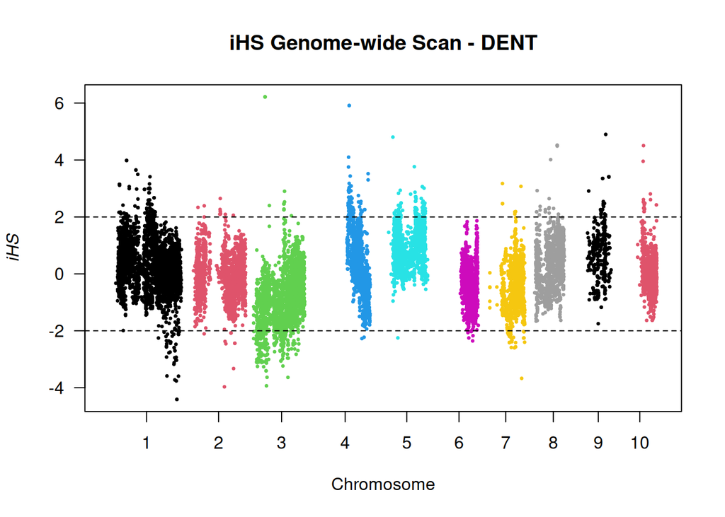

```r
################################################################################
# ETAPA 1: VARREDURA GENÔMICA (scan_hh) PARA DENT E FLINT
################################################################################

executar_scan_hh_pop <- function(matriz_genotipos, mapa_snps) {

  mapa_rehh <- mapa_snps %>%
    transmute(
      marker_id = as.character(marcador),
      chr       = as.character(chr),
      pos       = as.numeric(pos)
    )

  matriz_recodificada <- matrix(0, nrow = nrow(matriz_genotipos), ncol = ncol(matriz_genotipos),
                                dimnames = dimnames(matriz_genotipos))
  matriz_recodificada[matriz_genotipos == 0] <- 1
  matriz_recodificada[matriz_genotipos == 2] <- 2
  matriz_recodificada[matriz_genotipos == 1 | is.na(matriz_genotipos)] <- 0

  lista_hh <- list()
  cromossomos <- sort(unique(as.numeric(mapa_rehh$chr)))

  for (c in cromossomos) {
    snps_chr <- mapa_rehh %>% filter(chr == as.character(c)) %>% pull(marker_id)
    mapa_chr <- mapa_rehh %>% filter(chr == as.character(c))
    mat_chr  <- matriz_recodificada[, snps_chr, drop = FALSE]

    ids_ind <- if (!is.null(rownames(mat_chr))) rownames(mat_chr) else paste0("Ind_", 1:nrow(mat_chr))
    df_hap  <- cbind(ID = ids_ind, as.data.frame(mat_chr, stringsAsFactors = FALSE))

    tmp_hap <- tempfile(fileext = ".hap")
    tmp_map <- tempfile(fileext = ".map")
    write.table(df_hap, file = tmp_hap, row.names = FALSE, col.names = FALSE, quote = FALSE, sep = "\t")
    write.table(mapa_chr, file = tmp_map, row.names = FALSE, col.names = FALSE, quote = FALSE, sep = "\t")

    hh_obj <- tryCatch({
      data2haplohh(
        hap_file                = tmp_hap,
        map_file                = tmp_map,
        chr.name                = as.character(c),
        allele_coding           = "12",
        min_perc_geno.mrk       = 80,
        remove_multiple_markers = TRUE,
        verbose                 = FALSE
      )
    }, error = function(e) NULL)

    unlink(c(tmp_hap, tmp_map))

    if (!is.null(hh_obj)) {
      # Calcula iHH e iES ao longo do cromossomo
      scan_res <- scan_hh(hh_obj, polarized = FALSE)
      lista_hh[[as.character(c)]] <- list(obj = hh_obj, scan = scan_res)
    }
  }
  return(lista_hh)
}

# Processar as populações
res_DENT  <- executar_scan_hh_pop(matriz_CFDENT_rehh, mapa_haplotipos_unicos)
res_FLINT <- executar_scan_hh_pop(matriz_CFFLINT_rehh, mapa_haplotipos_unicos)


################################################################################
# ETAPA 2: CÁLCULO DO iHS EM TODO O GENOMA (ihh2ihs)
################################################################################

# Unificar os resultados do scan_hh por grupo
scan_DENT_df  <- bind_rows(lapply(res_DENT, function(x) x$scan))
scan_FLINT_df <- bind_rows(lapply(res_FLINT, function(x) x$scan))

# Calcular iHS padronizado (min_maf = 0.05 ignora alelos raros)
ihs_DENT  <- ihh2ihs(scan_DENT_df, min_maf = 0.05)
## Discard focal markers with Minor Allele Frequency equal to or below 0.05 .
## 4386 markers discarded.
## 33298 markers remaining.
ihs_FLINT <- ihh2ihs(scan_FLINT_df, min_maf = 0.05)
## Discard focal markers with Minor Allele Frequency equal to or below 0.05 .
## 6742 markers discarded.
## 30940 markers remaining.

# 1. Gráficos de Manhattan para iHS
manhattanplot(ihs_DENT, pvalue = FALSE, main = "iHS Genome-wide Scan - DENT")
```

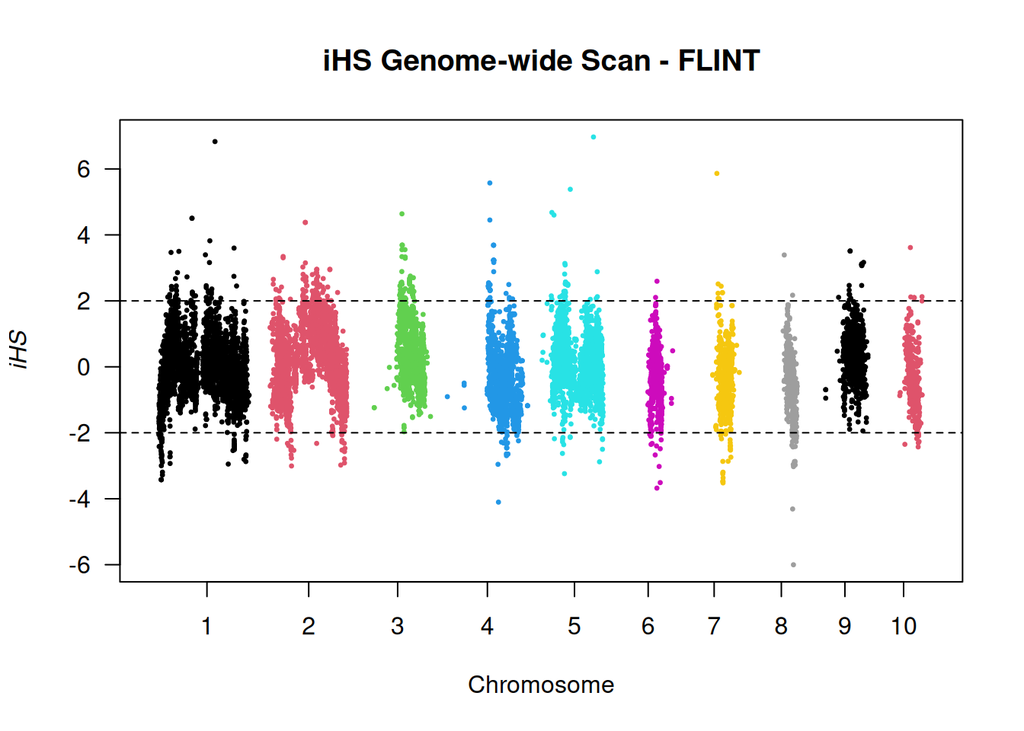

```r
manhattanplot(ihs_FLINT, pvalue = FALSE, main = "iHS Genome-wide Scan - FLINT")
```

```r
# 2. Extrair os Marcadores Candidatos Top (|iHS| > 2 ou p-value elevado)
top_ihs_DENT <- ihs_DENT$ihs %>%
  filter(abs(IHS) > 2) %>%
  arrange(desc(abs(IHS)))

top_ihs_FLINT <- ihs_FLINT$ihs %>%
  filter(abs(IHS) > 2) %>%
  arrange(desc(abs(IHS)))

cat("=== TOP CANDIDATOS iHS EM DENT (|iHS| > 2) ===\n")
## === TOP CANDIDATOS iHS EM DENT (|iHS| > 2) ===
print(head(top_ihs_DENT, 10))
```

```
##               CHR  POSITION      IHS LOGPVALUE
## PZE-103049101   3  53143210 6.216980  9.295151
## PZE-103049110   3  53143525 6.216980  9.295151
## PZE-103049112   3  53143637 6.216980  9.295151
## PZE-104068545   4 136078574 5.913733  8.475682
## PZE-104068550   4 136083034 5.913733  8.475682
## PZE-109063769   9 106474913 4.899256  6.016823
## PZE-105057439   5  55948933 4.805211  5.810823
## PZE-108057498   8 102655098 4.517057  5.202697
## PZE-108057503   8 102655842 4.517057  5.202697
## PZE-110047385  10  88571148 4.505221  5.178460
```

```r
cat("\n=== TOP CANDIDATOS iHS EM FLINT (|iHS| > 2) ===\n")
```

```
##
## === TOP CANDIDATOS iHS EM FLINT (|iHS| > 2) ===
```

```r
print(head(top_ihs_FLINT, 10))
```

```
##               CHR  POSITION       IHS LOGPVALUE
## PZE-105105286   5 159946189  6.968493 11.494371
## PZE-101132989   1 172022100  6.829963 11.070905
## SYN3437         8 120459721 -6.001948  8.710046
## SYN25397        7  95430917  5.863617  8.344006
## PZE-104064423   4 127200382  5.574106  7.604143
## PZE-105082404   5  97534082  5.382680  7.134394
## SYN27921        5  47973142  4.680045  5.542404
## PZE-103077002   3 127602210  4.638751  5.455287
## SYN8808         5  53624586  4.601857  5.378054
## PZE-101106230   1 110079962  4.503511  5.174963
```

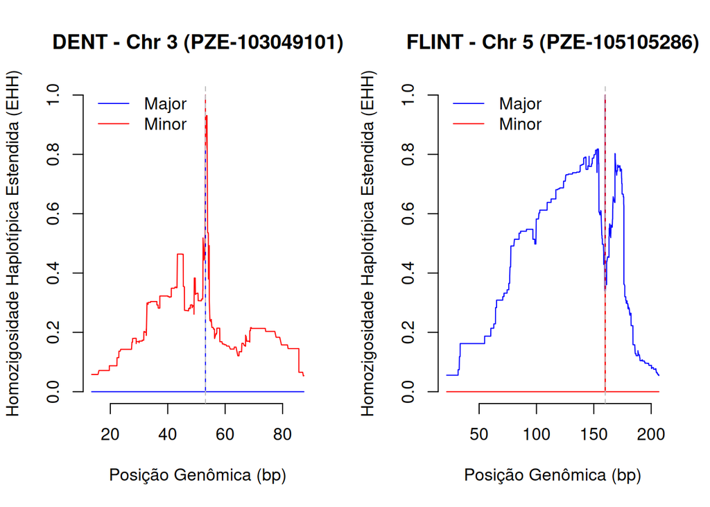

```r
################################################################################
# ETAPA 3: CÁLCULO DO rEHH EM MARCADORES FOCAIS (calc_ehh)
################################################################################

# O rEHH é calculado ao redor do marcador focal para analisar o decaimento haplotípico.
# Exemplo: Selecionar o principal SNP candidato retornado pelo iHS em DENT

# Preservar os rownames (IDs dos SNPs) em uma coluna dedicada 'mrk_id'
ihs_DENT_df <- ihs_DENT$ihs %>%
  mutate(mrk_id = rownames(ihs_DENT$ihs))

ihs_FLINT_df <- ihs_FLINT$ihs %>%
  mutate(mrk_id = rownames(ihs_FLINT$ihs))

# Extrair os top candidatos (|iHS| > 2)
top_ihs_DENT <- ihs_DENT_df %>%
  filter(abs(IHS) > 2) %>%
  arrange(desc(abs(IHS)))

top_ihs_FLINT <- ihs_FLINT_df %>%
  filter(abs(IHS) > 2) %>%
  arrange(desc(abs(IHS)))
# integrated haplotype score (iHS)
snp_focal_id <- top_ihs_DENT$mrk_id[1]
chr_focal    <- as.character(top_ihs_DENT$CHR[1])

cat("Marcador Focal Selecionado:", snp_focal_id, "\n")
## Marcador Focal Selecionado: PZE-103049101
cat("Cromossomo:", chr_focal, "\n")
## Cromossomo: 3

# Obter o objeto haplohh correspondente àquele cromossomo
hh_chr_target <- res_DENT[[chr_focal]]$obj

# Calcular EHH e rEHH ao redor do SNP focal
ehh_res <- calc_ehh(
  haplohh   = hh_chr_target,
  mrk       = snp_focal_id,  # Passa a string exata do nome do SNP
  polarized = FALSE,
  limehh    = 0.05
)


# Configurar painel gráfico para exibir os 2 gráficos lado a lado
par(mfrow = c(1, 2))


################################################################################
# 1. DECAIMENTO DE EHH NO POOL DENT (Cromossomo 3: 53.14 Mb)
################################################################################

# Calcular EHH no SNP líder do grupo DENT
ehh_DENT_top <- calc_ehh(
  haplohh   = res_DENT[["3"]]$obj,
  mrk       = "PZE-103049101",
  polarized = FALSE,
  limehh    = 0.05
)

# Gerar o gráfico
plot(
  ehh_DENT_top,
  main = "DENT - Chr 3 (PZE-103049101)",
  xlab = "Posição Genômica (bp)",
  ylab = "Homozigosidade Haplotípica Estendida (EHH)"
)


################################################################################
# 2. DECAIMENTO DE EHH NO POOL FLINT (Cromossomo 5: 159.94 Mb)
################################################################################

# Calcular EHH no SNP líder do grupo FLINT
ehh_FLINT_top <- calc_ehh(
  haplohh   = res_FLINT[["5"]]$obj,
  mrk       = "PZE-105105286",
  polarized = FALSE,
  limehh    = 0.05
)

# Gerar o gráfico
plot(
  ehh_FLINT_top,
  main = "FLINT - Chr 5 (PZE-105105286)",
  xlab = "Posição Genômica (bp)",
  ylab = "Homozigosidade Haplotípica Estendida (EHH)"
)
```

```r
# Restaurar layout gráfico original
par(mfrow = c(1, 1))
```

The integrated haplotype score ($iHS$) and extended haplotype homozygosity ($EHH$) provide a direct molecular framework for defining and detecting selection signatures created by recent directional selection. When positive selection favors a beneficial mutation, the target allele rapidly increases in frequency within a population. Because this selective sweep occurs much faster than historical recombination can break down linked genetic variation, the beneficial allele carries along an extended block of surrounding loci, a process known as genetic hitchhiking. This mechanism leaves a distinct selection signature characterized by unusually long, highly homozygous haplotype tracts associated with the favored allele compared to alternative background alleles at the same locus.

The magnitude and distribution of $iHS$ and $EHH$ metrics allow us to characterize the underlying evolutionary dynamics of these selection signatures. In our doubled haploid panels, extreme scores such as $iHS = +6.217$ in Dent (Chromosome 3 at 53.14 Mb) and $iHS = +6.968$ in Flint (Chromosome 5 at 159.95 Mb) pinpoint primary selection signatures driven by intense positive selection. Haplotype-based scans are uniquely suited for detecting soft or partial selective sweeps, where beneficial alleles are selected from standing genetic variation or have not yet reached complete fixation across all subpopulations. In these regions, extreme $iHS$ scores highlight candidate loci where selection operated rapidly on specific ancestral or derived haplotype backgrounds.

The asymmetry observed in $EHH$ decay curves around lead focal markers serves as visual and quantitative validation of these selection signatures. In genomic regions evolving neutrally, linkage disequilibrium decays symmetrically and at similar rates for both major and minor alleles. In contrast, the pronounced extension of $EHH$ on the minor allele background of PZE-103049101 in Dent (spanning over 60 Mb) and on the major allele background of PZE-105105286 in Flint (spanning over 130 Mb) demonstrates that recombination was bypassed due to the rapid frequency rise of the selected haplotype. This striking disparity between core allele backgrounds confirms that these genomic regions represent genuine selection signatures rather than stochastic effects of genetic drift or uniform genome-wide autozygosity.

Correlating $iHS$ and $EHH$ results with single-locus differentiation ($F_{ST}$) and site frequency spectrum metrics (Tajima’s $D$) completes the identification of selection signatures across different evolutionary stages in the maize genome. While Tajima’s $D$ captures sweeps near complete fixation through an excess of rare variants, and $F_{ST}$ detects loci differentially fixed between Dent and Flint germplasm groups, $iHS$ isolates recent or ongoing selective sweeps where extended haplotype integrity remains preserved. Together, these complementary statistics confirm that the candidate sweep regions identified on Chromosomes 3, 4, 5, and 8 represent major selection signatures targeting key agronomic and adaptive loci involved in the divergence of Dent and Flint maize inbred lines.

### Reduced local variability

Methods based on reduced or altered local variability focus on identifying genomic regions where genotype distributions depart significantly from genome-wide expectations. While selective sweeps traditionally create extended Runs of Homozygosity (ROHom) through the hitchhiking of favorable alleles, mapping Runs of Heterozygosity (ROHet) provides crucial insights into balancing selection, residual heterozygosity, and genomic regions associated with heterosis or overdominance.

Runs of Homozygosity (ROH) are DNA segments that harbor uninterrupted stretches of loci that are homozygous in an individual but remain polymorphic across the broader population. Broman and Weber (1999) were the first to suggest that ROHs are likely autozygous, proposing a statistical method based on LOD scores to evaluate autozygosity proportions in human outbred populations. Although a long stretch of homozygous loci in an individual does not necessarily guarantee inheritance from a common ancestor without recombination, extended ROHs are widely used to provide genome-wide estimates of autozygosity (McQuillan et al., 2008; Kirin et al., 2010; Keller et al., 2011). While ROHs can arise from several evolutionary processes, inbreeding is recognized as their primary driver (Broman and Weber, 1999; Gibson et al., 2006). Under hitchhiking theory, positive selection also drives beneficial alleles toward fixation, creating extended ROHs around target loci.

#### ROHom and ROHet Calculation

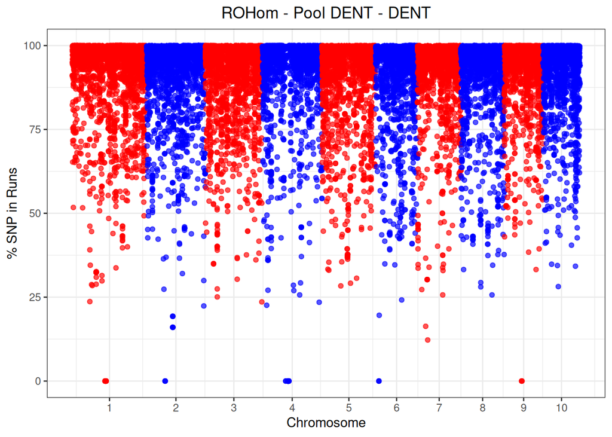

```r
##### AGORA VAMOS CALCULAR COM BASE EM OUTRO METODOS USANDO O PACOTE detectRUNS
##### Methods based on reduced local variability
# This is the main detectRUNS function to scan the genome for runs (of homozygosity or heterozygosity)
# using the consecutive method (Marras et al. 2015, Animal Genetics 46(2):110-121).#####

library(tidyverse)
library(detectRUNS)
################################################################################
# ETAPA 1: CONVERTER E EXPORTAR PARA PLINK (.ped E .map) (AI)
################################################################################

exportar_plink_ped_map <- function(matriz_genotipos, mapa_snps, prefixo_arquivo, grupo_nome = "POP") {

  df_map <- mapa_snps %>%
    transmute(
      chr = as.character(chr),
      snp = as.character(marcador),
      cM  = 0,
      pos = as.numeric(pos)
    )

  file_map <- paste0(prefixo_arquivo, ".map")
  write.table(df_map, file = file_map, col.names = FALSE, row.names = FALSE, quote = FALSE, sep = "\t")

  mat_gen <- matriz_genotipos[, df_map$snp, drop = FALSE]
  n_ind <- nrow(mat_gen)
  n_snp <- ncol(mat_gen)

  ids <- if (!is.null(rownames(mat_gen))) rownames(mat_gen) else paste0("Ind_", 1:n_ind)

  header_ped <- data.frame(
    FID   = grupo_nome,
    IID   = ids,
    PID   = 0, MID = 0, Sex = 0, Pheno = -9,
    stringsAsFactors = FALSE
  )

  gen_pairs <- matrix("0 0", nrow = n_ind, ncol = n_snp)
  gen_pairs[mat_gen == 0] <- "1 1"
  gen_pairs[mat_gen == 2] <- "2 2"
  gen_pairs[mat_gen == 1] <- "1 2"
  gen_pairs[is.na(mat_gen)] <- "0 0"

  file_ped <- paste0(prefixo_arquivo, ".ped")
  ped_lines <- apply(cbind(header_ped, gen_pairs), 1, paste, collapse = " ")
  writeLines(ped_lines, con = file_ped)

  return(list(ped = file_ped, map = file_map))
}

# Gerar arquivos de entrada PLINK
files_dent  <- exportar_plink_ped_map(matriz_CFDENT_rehh, mapa_haplotipos_unicos, "dados_DENT", "DENT")
files_flint <- exportar_plink_ped_map(matriz_CFFLINT_rehh, mapa_haplotipos_unicos, "dados_FLINT", "FLINT")


################################################################################
# DETECÇÃO DE ROHom E ROHet (MÉTODO CONSECUTIVO MARRAS ET AL., 2015) (AI)
################################################################################

# Parâmetros calibrados para o chip SNP de milho:
# - minSNP = 15 marcadores
# - minLengthBps = 100 kb (100.000 bp)
# - maxGap = 1 Mb (1.000.000 bp)
# - maxOppRun = 1 / maxMissRun = 1

# --- 2.1. RUNS DE HOMOZIGOSIDADE (ROHom - Varreduras Seletivas / IBD) ---
rohom_DENT <- consecutiveRUNS.run(
  genotypeFile = files_dent$ped, mapFile = files_dent$map,
  ROHet = FALSE, maxOppRun = 1, maxMissRun = 1,
  minSNP = 15, minLengthBps = 100000, maxGap = 1e6
)

rohom_FLINT <- consecutiveRUNS.run(
  genotypeFile = files_flint$ped, mapFile = files_flint$map,
  ROHet = FALSE, maxOppRun = 1, maxMissRun = 1,
  minSNP = 15, minLengthBps = 100000, maxGap = 1e6
)

# --- 2.2. RUNS DE HETEROZIGOSIDADE (ROHet - Diversidade Mantida / Heterose) ---
rohet_DENT <- consecutiveRUNS.run(
  genotypeFile = files_dent$ped, mapFile = files_dent$map,
  ROHet = TRUE, maxOppRun = 1, maxMissRun = 1,
  minSNP = 15, minLengthBps = 100000, maxGap = 1e6
)

rohet_FLINT <- consecutiveRUNS.run(
  genotypeFile = files_flint$ped, mapFile = files_flint$map,
  ROHet = TRUE, maxOppRun = 1, maxMissRun = 1,
  minSNP = 15, minLengthBps = 100000, maxGap = 1e6
)


# CLASSIFICAÇÃO POR CLASSES DE COMPRIMENTO (MARRAS ET AL., 2015)

# Marras et al. (2015) categorizam as corridas em classes físicas para diferenciar
# endogamia antiga/ancestral (ROH curtos) de endogamia recente (ROH longos).

classificar_runs_kirin <- function(df_runs) {
  if (is.null(df_runs) || nrow(df_runs) == 0) return(NULL)

  df_runs %>%
    mutate(
      length_mb = lengthBps / 1e6,
      Class = case_when(
        length_mb < 2                   ~ "< 2 Mb (Ancestral)",
        length_mb >= 2 & length_mb < 4  ~ "2-4 Mb",
        length_mb >= 4 & length_mb < 8  ~ "4-8 Mb",
        length_mb >= 8 & length_mb < 16 ~ "8-16 Mb",
        length_mb >= 16                 ~ "> 16 Mb (Recente)"
      ),
      Class = factor(
        Class,
        levels = c("< 2 Mb (Ancestral)", "2-4 Mb", "4-8 Mb", "8-16 Mb", "> 16 Mb (Recente)")
      )
    )
}

rohom_DENT_class  <- classificar_runs_kirin(rohom_DENT)
rohom_FLINT_class <- classificar_runs_kirin(rohom_FLINT)
rohet_DENT_class  <- classificar_runs_kirin(rohet_DENT)
rohet_FLINT_class <- classificar_runs_kirin(rohet_FLINT)


################################################################################
# CONSANGUINIDADE GENÔMICA (F_ROH) E PERFIL POPULACIONAL (AI)
################################################################################

tamanho_genoma_milho <- 2.1e9 # ~2.1 Gb para B73

calcular_froh_pop <- function(df_runs, n_ind_total, pop_nome, tipo_run) {
  if (is.null(df_runs) || nrow(df_runs) == 0) {
    return(data.frame(Populacao = pop_nome, Tipo = tipo_run, N_Runs_Total = 0, F_medio = 0))
  }

  froh_ind <- df_runs %>%
    group_by(id) %>%
    summarise(
      n_runs = n(),
      soma_bp = sum(lengthBps),
      F_coeff = soma_bp / tamanho_genoma_milho,
      .groups = "drop"
    )

  data.frame(
    Populacao      = pop_nome,
    Tipo           = tipo_run,
    N_Individuos   = n_ind_total,
    N_Runs_Total   = nrow(df_runs),
    Mean_Runs_Ind  = nrow(df_runs) / n_ind_total,
    Mean_F_coeff   = mean(froh_ind$F_coeff, na.rm = TRUE),
    Sd_F_coeff     = sd(froh_ind$F_coeff, na.rm = TRUE)
  )
}

tabela_marras_resumo <- bind_rows(
  calcular_froh_pop(rohom_DENT, nrow(matriz_CFDENT_rehh), "DENT", "ROHom (Homozigosidade)"),
  calcular_froh_pop(rohom_FLINT, nrow(matriz_CFFLINT_rehh), "FLINT", "ROHom (Homozigosidade)"),
  calcular_froh_pop(rohet_DENT, nrow(matriz_CFDENT_rehh), "DENT", "ROHet (Heterozigosidade)"),
  calcular_froh_pop(rohet_FLINT, nrow(matriz_CFFLINT_rehh), "FLINT", "ROHet (Heterozigosidade)")
)

################################################################################
# DETECÇÃO DE ILHAS DE SELEÇÃO (ROHom ISLANDS E ROHet ISLANDS) (AI)
################################################################################

# ==============================================================================
# 1. SUMÁRIOS ESTATÍSTICOS E F_ROH
# ==============================================================================
all_rohom <- dplyr::bind_rows(rohom_DENT, rohom_FLINT)
all_rohet <- dplyr::bind_rows(rohet_DENT, rohet_FLINT)
# Sumários completos por população (divididos em classes de tamanho)
summary_DENT <- summaryRuns(
  runs         = rohom_DENT,
  mapFile      = files_dent$map,
  genotypeFile = files_dent$ped,
  Class        = 6,
  snpInRuns    = TRUE
)

summary_FLINT <- summaryRuns(
  runs         = rohom_FLINT,
  mapFile      = files_flint$map,
  genotypeFile = files_flint$ped,
  Class        = 6,
  snpInRuns    = TRUE
)

# Unificar estimativas individuais de consanguinidade (F_ROH)
froh_all <- rbind(
  summary_DENT$result_Froh_genome_wide,
  summary_FLINT$result_Froh_genome_wide
)


# ==============================================================================
# 2. IDENTIFICAÇÃO DE ILHAS DE ROH (THRESHOLD > 40%)
# ==============================================================================

# Tabela com SNPs presentes em ROH em mais de 40% da população
ilhas_DENT_40 <- tableRuns(
  runs         = rohom_DENT,
  genotypeFile = files_dent$ped,
  mapFile      = files_dent$map,
  threshold    = 0.40
)

ilhas_FLINT_40 <- tableRuns(
  runs         = rohom_FLINT,
  genotypeFile = files_flint$ped,
  mapFile      = files_flint$map,
  threshold    = 0.40
)


# ==============================================================================
# 3. MANHATTAN PLOTS DE ROH (FREQUÊNCIA DE SNPS EM RUNS)
# ==============================================================================

# Manhattan Plot - Pool DENT
plot_manhattanRuns(
  runs         = rohom_DENT,
  genotypeFile = files_dent$ped,
  mapFile      = files_dent$map,
  plotTitle    = "ROHom - Pool DENT"
)
```

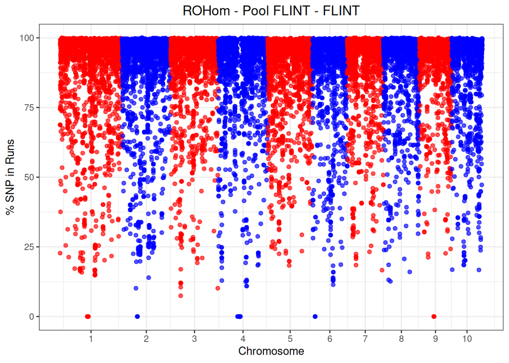

```r
# Manhattan Plot - Pool FLINT
plot_manhattanRuns(
  runs         = rohom_FLINT,
  genotypeFile = files_flint$ped,
  mapFile      = files_flint$map,
  plotTitle    = "ROHom - Pool FLINT"
)
```

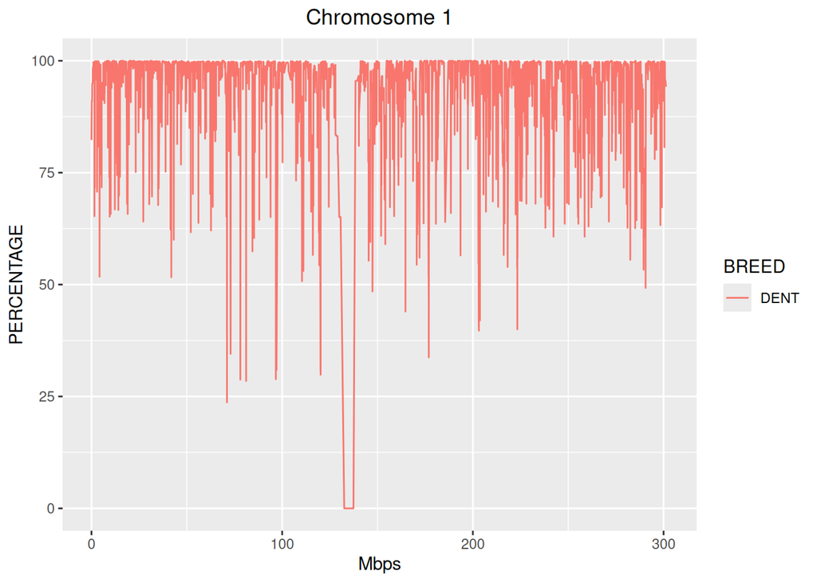

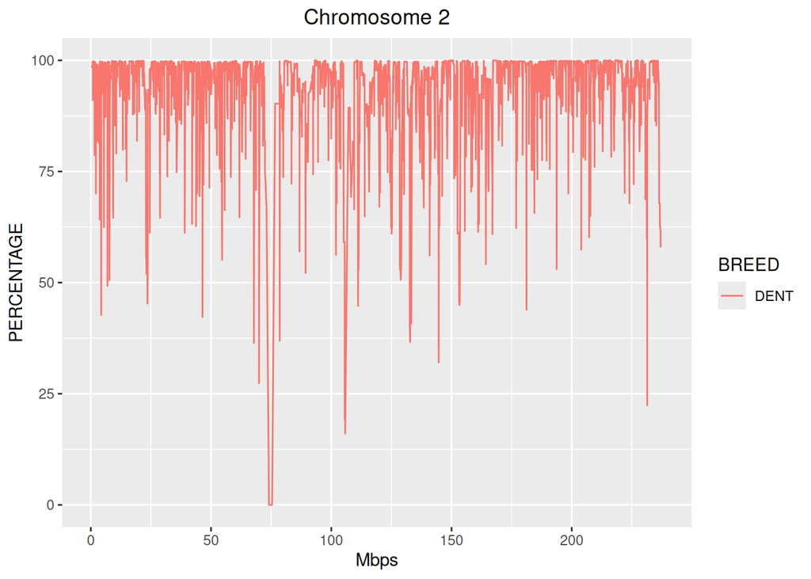

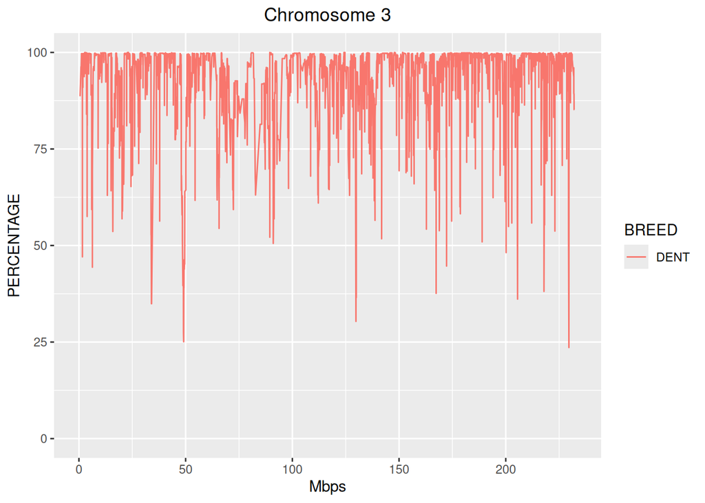

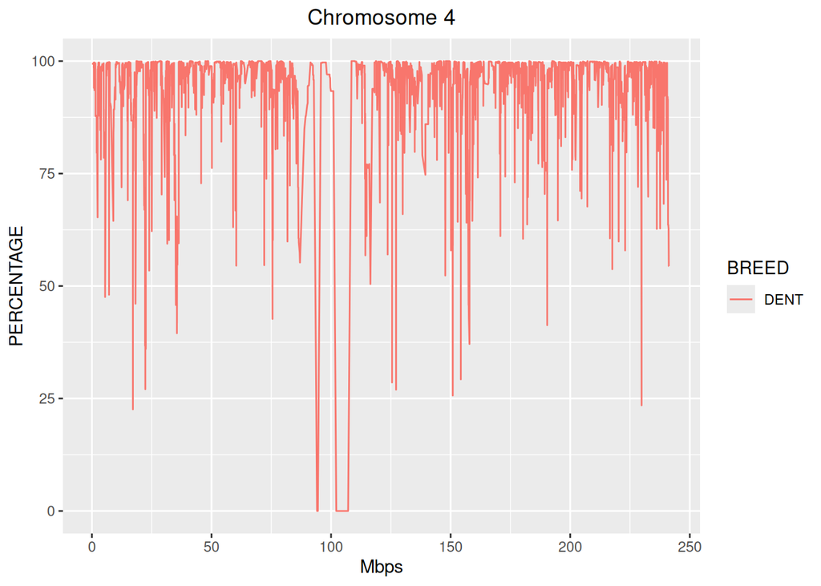

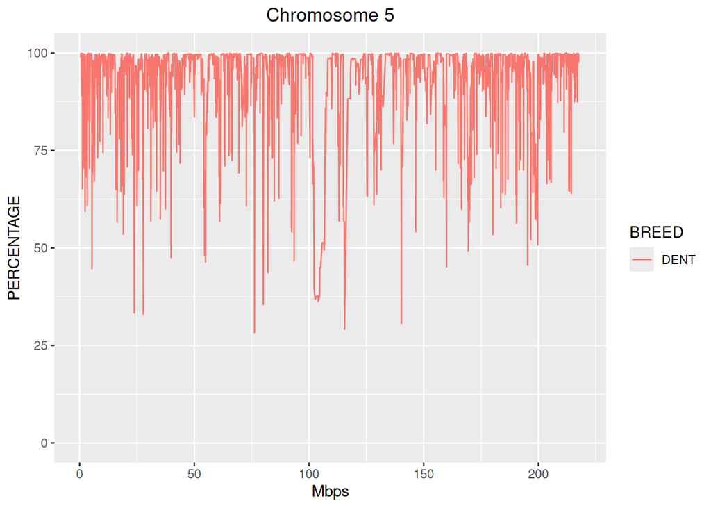

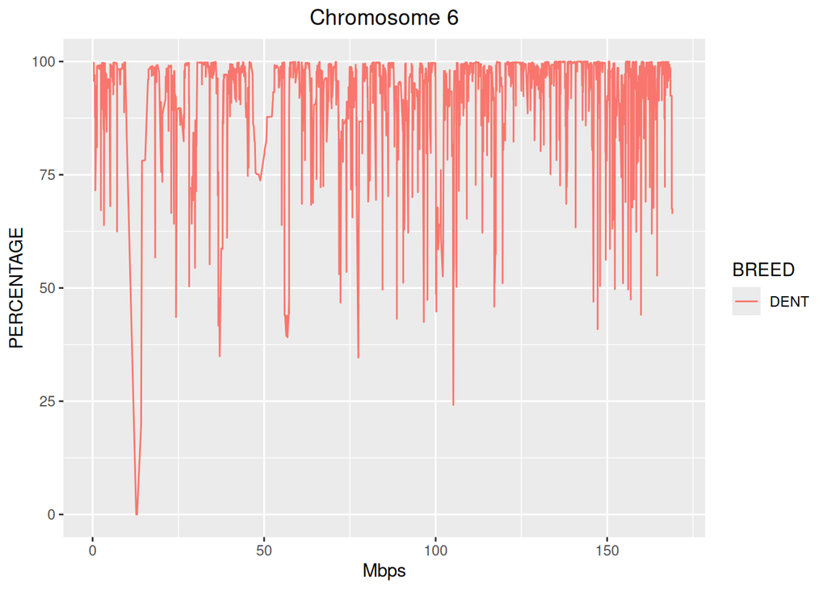

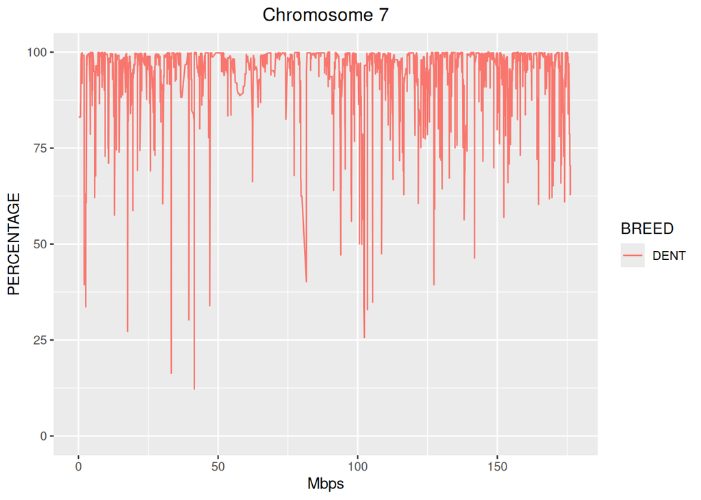

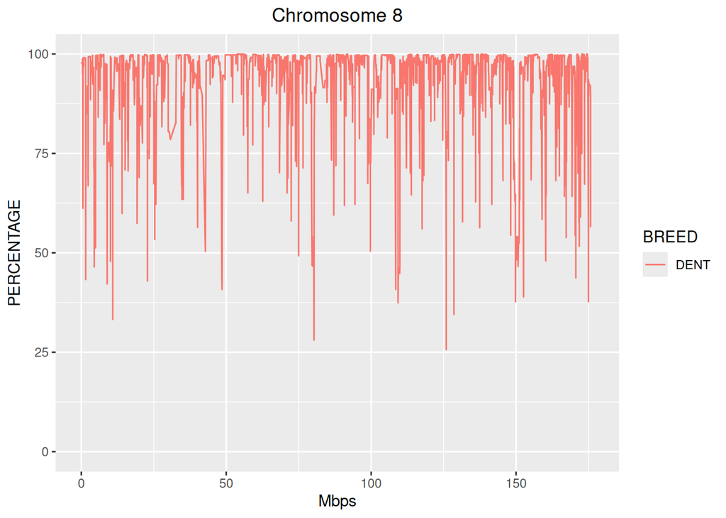

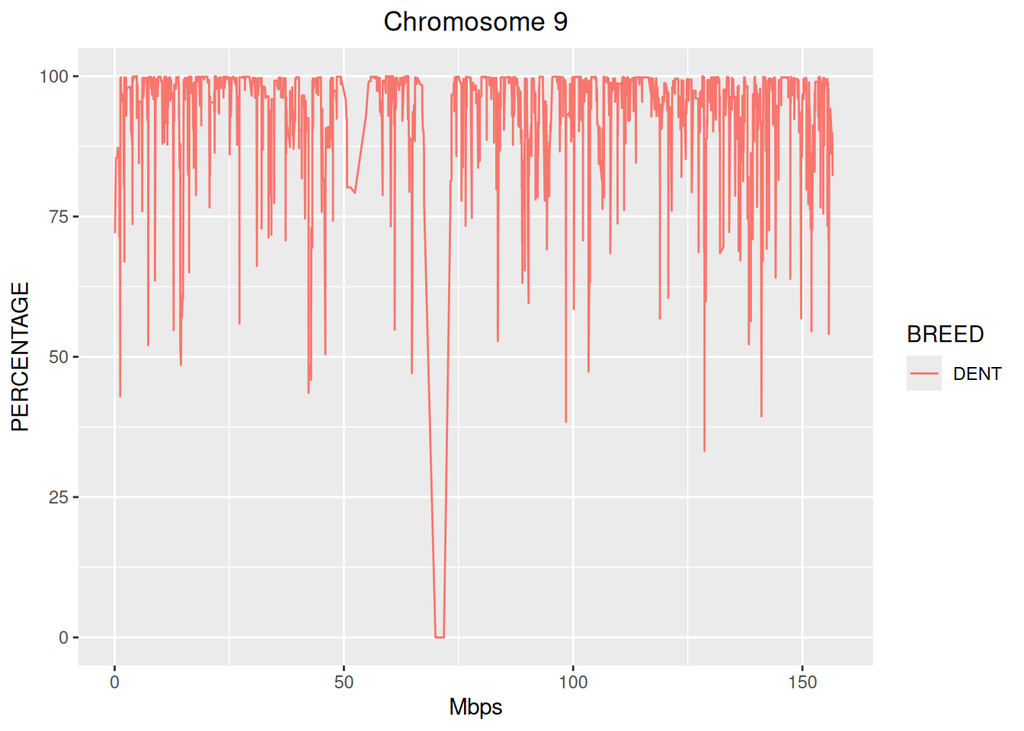

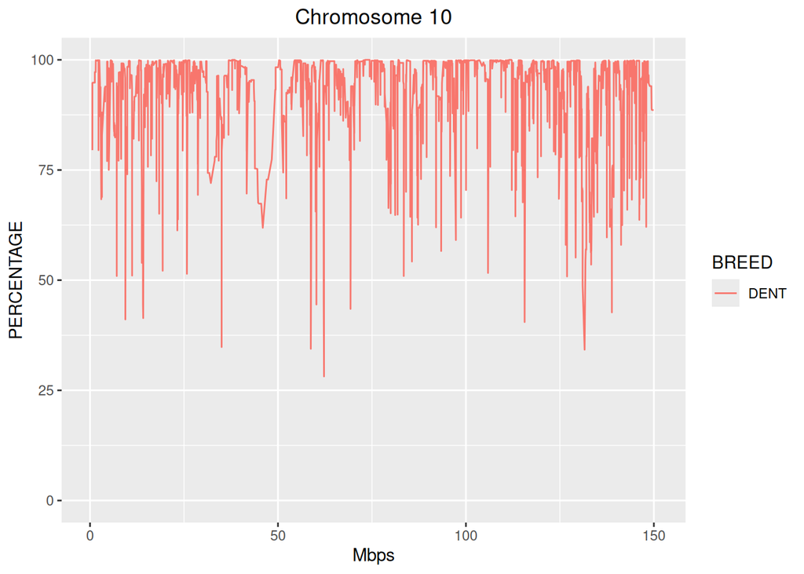

```r
# ==============================================================================
# 4. MAPEAMENTO DE PICOS GENÔMICOS (SNPS IN RUNS POR POPULAÇÃO)
# ==============================================================================

# Proporção de SNPs em ROH no Genoma Completo - DENT
plot_SnpsInRuns(
  runs         = rohom_DENT,
  genotypeFile = files_dent$ped,
  mapFile      = files_dent$map
)
```

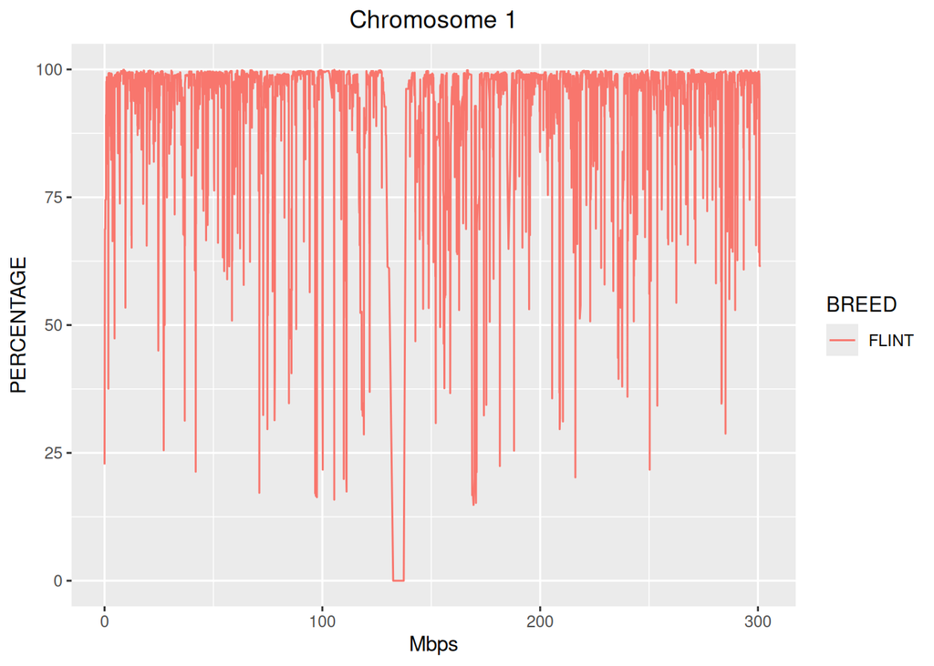

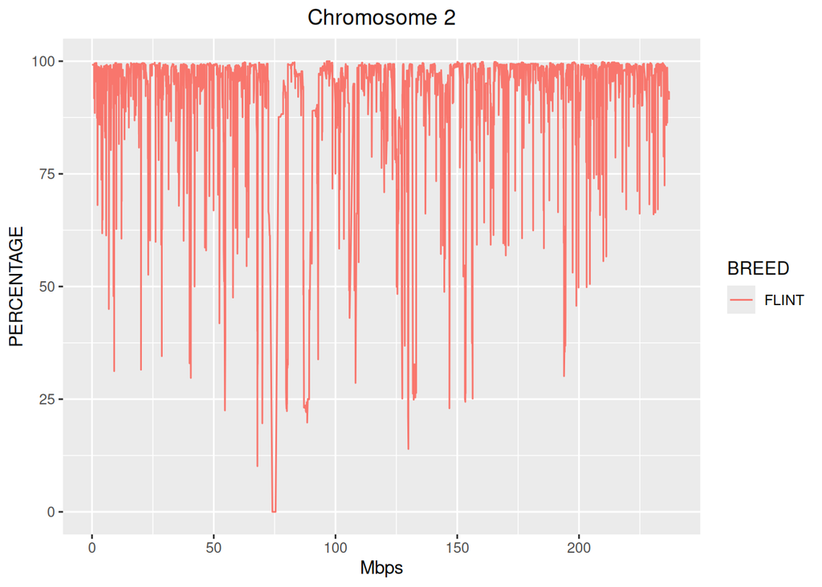

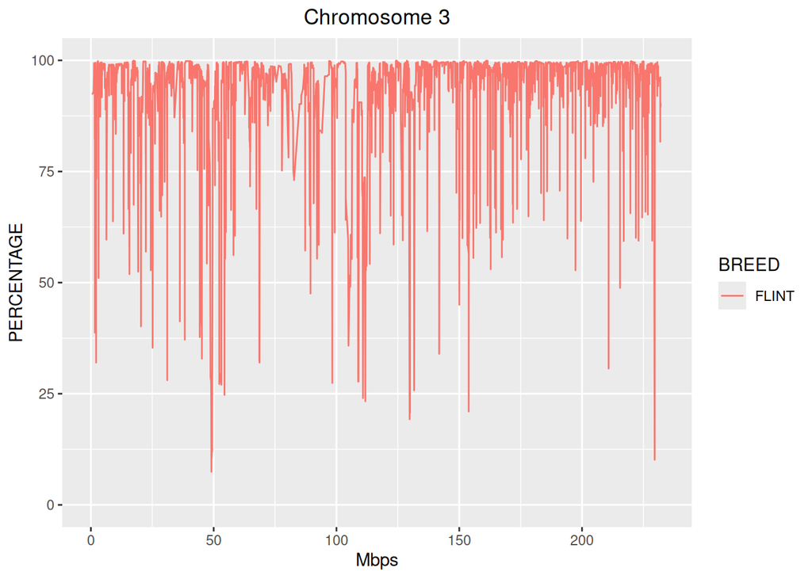

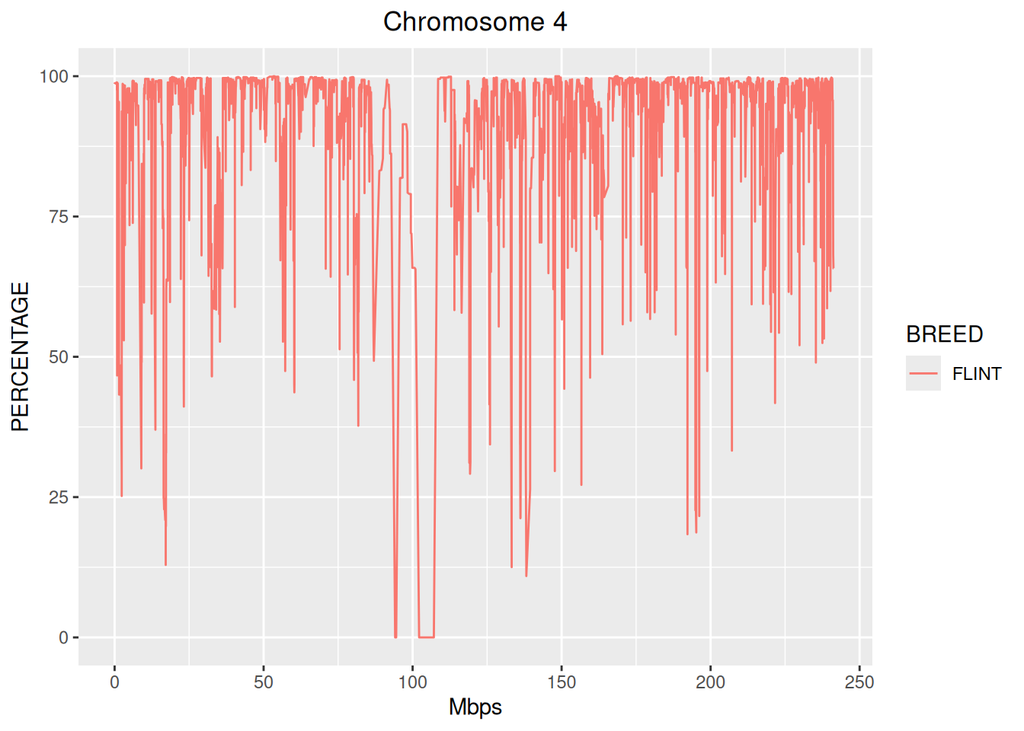

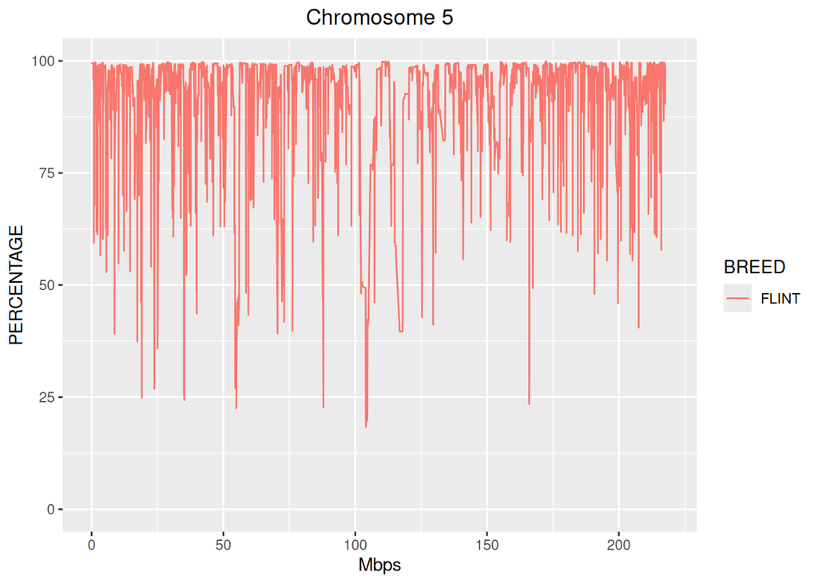

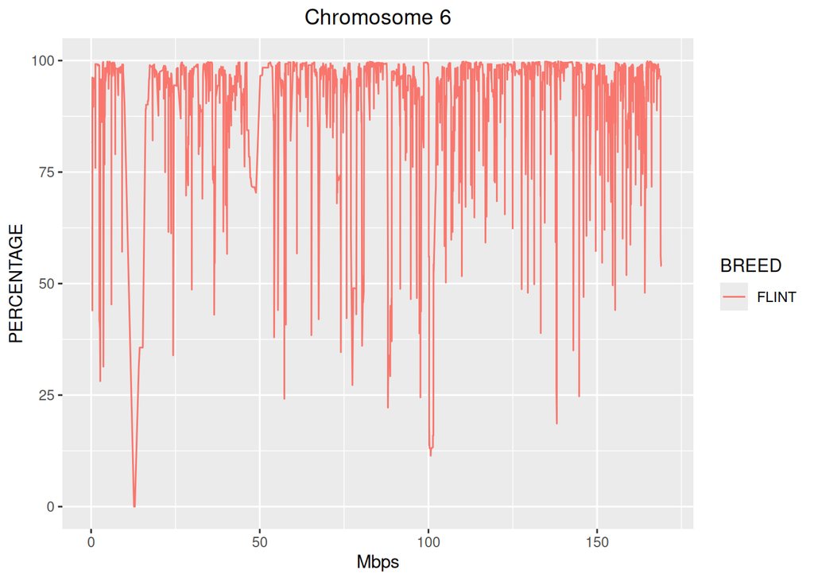

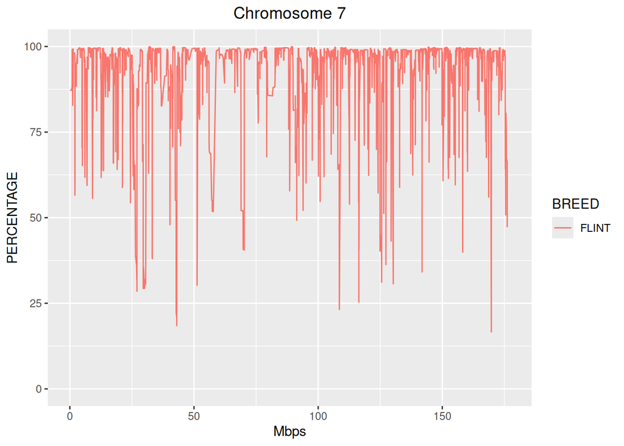

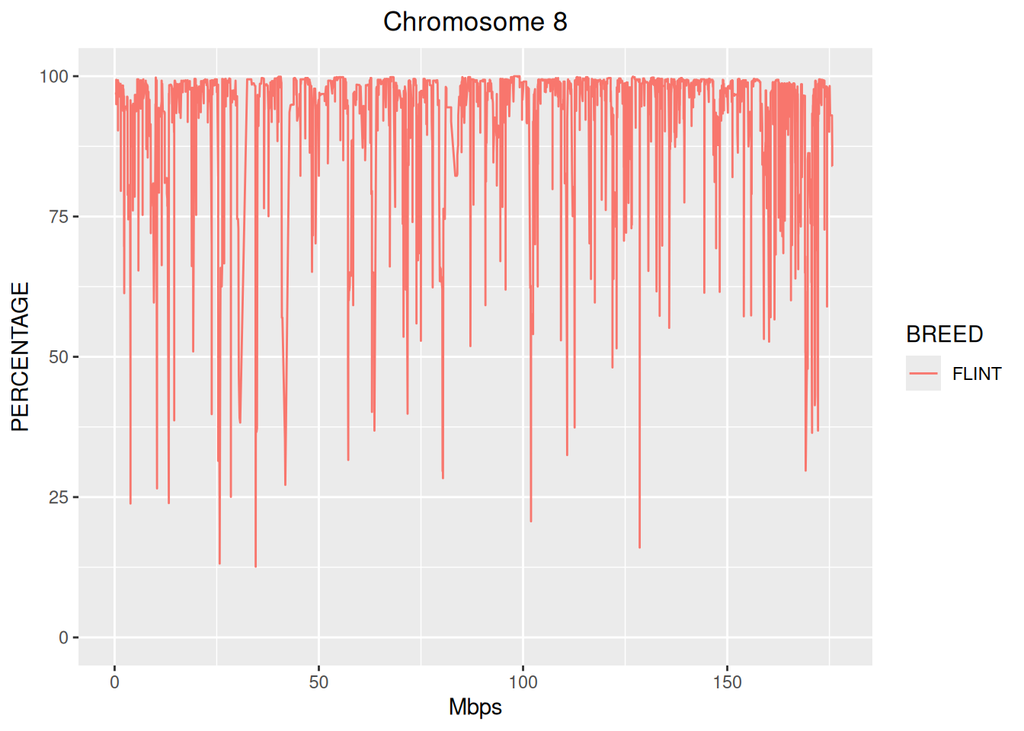

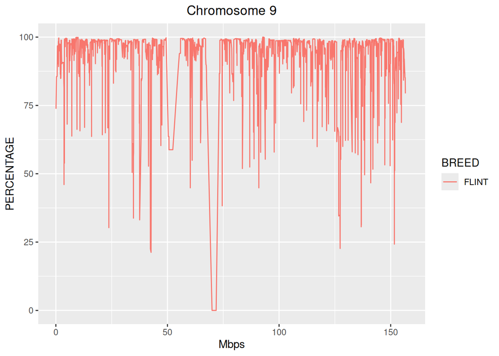

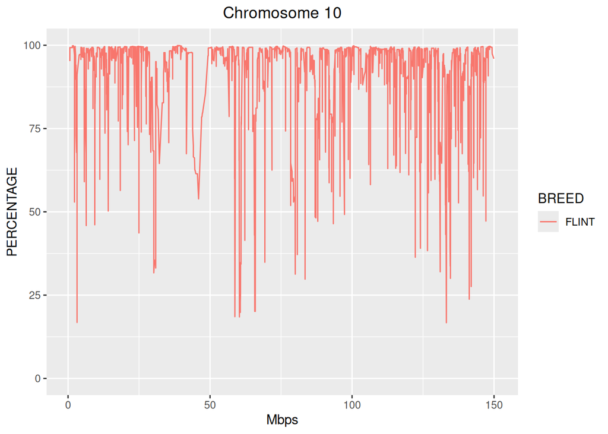

```r
# Proporção de SNPs em ROH no Genoma Completo - FLINT
plot_SnpsInRuns(
  runs         = rohom_FLINT,
  genotypeFile = files_flint$ped,
  mapFile      = files_flint$map
)
```